# Project_Full_Code_Notebook_EasyVisa_RDMET

[figure not shown]

Data Science with Generative AI: Applications to Business

Robust Data Modeling with Ensembling and Tuning Techniques

[figure not shown]

Visa Approval Facilitation

# **Problem Statement**

## Context

Business communities in the United States are facing high demand for human resources, but one of the constant challenges is identifying and attracting the right talent, which is perhaps the most important element in remaining competitive. Companies in the United States look for hard-working, talented, and qualified individuals both locally as well as abroad.

The Immigration and Nationality Act (INA) of the US permits foreign workers to come to the United States to work on either a temporary or permanent basis. The act also protects US workers against adverse impacts on their wages or working conditions by ensuring US employers' compliance with statutory requirements when they hire foreign workers to fill workforce shortages. The immigration programs are administered by the Office of Foreign Labor Certification (OFLC).

OFLC processes job certification applications for employers seeking to bring foreign workers into the United States and grants certifications in those cases where employers can demonstrate that there are not sufficient US workers available to perform the work at wages that meet or exceed the wage paid for the occupation in the area of intended employment.

## Objective

In FY 2016, the OFLC processed 775,979 employer applications for 1,699,957 positions for temporary and permanent labor certifications. This was a nine percent increase in the overall number of processed applications from the previous year. The process of reviewing every case is becoming a tedious task as the number of applicants is increasing every year.

The increasing number of applicants every year calls for a Machine Learning based solution that can help in shortlisting the candidates having higher chances of VISA approval. OFLC has hired the firm EasyVisa for data-driven solutions. You as a data scientist at EasyVisa have to analyze the data provided and, with the help of a classification model:

- Facilitate the process of visa approvals.
- Recommend a suitable profile for the applicants for whom the visa should be certified or denied based on the drivers that significantly influence the case status.

## Data Description

The data contains the different attributes of employee and the employer. The detailed data dictionary is given below.

- case_id: ID of each visa application
- continent: Information of continent the employee
- education_of_employee: Information of education of the employee
- has_job_experience: Does the employee has any job experience? Y= Yes; N = No
- requires_job_training: Does the employee require any job training? Y = Yes; N = No
- no_of_employees: Number of employees in the employer's company
- yr_of_estab: Year in which the employer's company was established
- region_of_employment: Information of foreign worker's intended region of employment in the US.
- prevailing_wage: Average wage paid to similarly employed workers in a specific occupation in the area of intended employment. The purpose of the prevailing wage is to ensure that the foreign worker is not underpaid compared to other workers offering the same or similar service in the same area of employment.
- unit_of_wage: Unit of prevailing wage. Values include Hourly, Weekly, Monthly, and Yearly.
- full_time_position: Is the position of work full-time? Y = Full Time Position; N = Part Time Position
- case_status: Flag indicating if the Visa was certified or denied

# **Importing necessary libraries**

```python
# Installing the libraries with the specified version.
#!pip install numpy==2.0.2 pandas==2.2.2 scikit-learn==1.6.1 matplotlib==3.10.0 seaborn==0.13.2 xgboost==3.0.5 -q --user
# Install the squarify library
!pip install squarify
```

```
Downloading squarify-0.4.4-py3-none-any.whl (4.1 kB)
```

**Note**: *After running the above cell, kindly restart the notebook kernel and run all cells sequentially from the start again.*

```python
import warnings

warnings.filterwarnings("ignore")

#data handling
import numpy as np
import pandas as pd

#visualizer libraries
import matplotlib.pyplot as plt
from statsmodels.graphics.mosaicplot import mosaic
import matplotlib.ticker as mticker
from matplotlib.patches import Patch
import squarify
import seaborn as sns

# To oversample and undersample data
from imblearn.over_sampling import SMOTE
from imblearn.under_sampling import RandomUnderSampler

# Importing pipeline function to avoid data leakage
from imblearn.pipeline import Pipeline as ImbPipeline


# Libraries different ensemble classifiers
from sklearn.ensemble import (
    BaggingClassifier,
    RandomForestClassifier,
    AdaBoostClassifier,
    GradientBoostingClassifier,
    StackingClassifier,
)

from xgboost import XGBClassifier
from sklearn.tree import DecisionTreeClassifier

# Libraries to get different metric scores
from sklearn import metrics
from sklearn.metrics import (
    confusion_matrix,
    accuracy_score,
    precision_score,
    recall_score,
    f1_score,
)

# To tune different models
from sklearn.model_selection import train_test_split, GridSearchCV
```

```python
# set defaults for the notebook

# Removes the limit for the number of displayed columns
pd.set_option("display.max_columns", None)

# Sets the limit for the number of displayed rows
pd.set_option("display.max_rows", 50)

#set a gray background grid for all visualizations
sns.set_style("darkgrid")

#turn off scientific notation
pd.set_option('display.float_format', lambda x: '%.2f' % x)
np.set_printoptions(suppress=True)
```

# **Loading the dataset**

```python
from google.colab import drive
drive.mount('/content/drive')
```

```python
path = "/content/drive/MyDrive/UT DS Grad Cert/Project 5/"
df = pd.read_csv(path + "EasyVisa.csv")
```

# **Overview of the Dataset**

- Observations
- Sanity checks

```python
df.head()
```

|  | case_id | continent | education_of_employee | has_job_experience | requires_job_training | no_of_employees | yr_of_estab | region_of_employment | prevailing_wage | unit_of_wage | full_time_position | case_status |
| --- | --- | --- | --- | --- | --- | --- | --- | --- | --- | --- | --- | --- |
| 0 | EZYV01 | Asia | High School | N | N | 14513 | 2007 | West | 592.20 | Hour | Y | Denied |
| 1 | EZYV02 | Asia | Master's | Y | N | 2412 | 2002 | Northeast | 83425.65 | Year | Y | Certified |
| 2 | EZYV03 | Asia | Bachelor's | N | Y | 44444 | 2008 | West | 122996.86 | Year | Y | Denied |
| 3 | EZYV04 | Asia | Bachelor's | N | N | 98 | 1897 | West | 83434.03 | Year | Y | Denied |
| 4 | EZYV05 | Africa | Master's | Y | N | 1082 | 2005 | South | 149907.39 | Year | Y | Certified |

```python
df.info()
```

```
<class 'pandas.core.frame.DataFrame'>
RangeIndex: 25480 entries, 0 to 25479
Data columns (total 12 columns):
 #   Column                 Non-Null Count  Dtype
---  ------                 --------------  -----
 0   case_id                25480 non-null  object
 1   continent              25480 non-null  object
 2   education_of_employee  25480 non-null  object
 3   has_job_experience     25480 non-null  object
 4   requires_job_training  25480 non-null  object
 5   no_of_employees        25480 non-null  int64
 6   yr_of_estab            25480 non-null  int64
 7   region_of_employment   25480 non-null  object
 8   prevailing_wage        25480 non-null  float64
 9   unit_of_wage           25480 non-null  object
 10  full_time_position     25480 non-null  object
 11  case_status            25480 non-null  object
dtypes: float64(1), int64(2), object(9)
memory usage: 2.3+ MB
```

```python
df.shape
```

```
(25480, 12)
```

There are 25,480 observations spread across 12 variables. Three variables are numeric: no_of_employees, yr_of_establishment, and prevailing_wage. The rest are categorical: case_id, continent, education_of_employee, has_job_experience, requires_job_training, region_of_employment, unit_of_wage, full_time_position, and case_status.

In this analysis, case_status is our variable of interest.

```python
#look for duplicate data values in df
df.duplicated().sum()
```

```
np.int64(0)
```

There are no duplicated values

```python
#look for unique data values in df
df.nunique()
```

|  | 0 |
| --- | --- |
| case_id | 25480 |
| continent | 6 |
| education_of_employee | 4 |
| has_job_experience | 2 |
| requires_job_training | 2 |
| no_of_employees | 7105 |
| yr_of_estab | 199 |
| region_of_employment | 5 |
| prevailing_wage | 25454 |
| unit_of_wage | 4 |
| full_time_position | 2 |
| case_status | 2 |

**dtype:** int64

```python
df.describe().T
```

|  | count | mean | std | min | 25% | 50% | 75% | max |
| --- | --- | --- | --- | --- | --- | --- | --- | --- |
| no_of_employees | 25480.00 | 5667.04 | 22877.93 | -26.00 | 1022.00 | 2109.00 | 3504.00 | 602069.00 |
| yr_of_estab | 25480.00 | 1979.41 | 42.37 | 1800.00 | 1976.00 | 1997.00 | 2005.00 | 2016.00 |
| prevailing_wage | 25480.00 | 74455.81 | 52815.94 | 2.14 | 34015.48 | 70308.21 | 107735.51 | 319210.27 |

Case id is a complete set of unique values and can be dropped prior to analysis. Prevailing wage is nearly completely unique; however, due to the different types (part-time, full-time, hourly, weekly, monthly, yearly), this is within reasonable expectations. There are no null values to be dealt with.

There are some interesting things that are worth noting in the numeric summary: there is a negative minimum value for no_of_employees. The minimum prevailing wage value is $2.1367, which seems low, be it for an hourly position or otherwise.

# **Exploratory Data Analysis (EDA)**

Below is a brief EDA of the most salient features. A full EDA can be found in the Appendix Section.

- EDA is an important part of any project involving data.
- It is important to investigate and understand the data better before building a model with it.
- A few questions have been mentioned below which will help you approach the analysis in the right manner and generate insights from the data.
- A thorough analysis of the data, in addition to the questions mentioned below, should be done.

**Leading Questions**

What is the distribution of visa case statuses (certified vs. denied)?

1. What is the distribution of visa case statuses (certified vs. denied)?
2. How does the education level of employees impact visa approval rates?
3. Is there a significant difference in visa approval rates between employees with and without prior job experience?
4. How does the prevailing wage affect visa approval? Do higher wages lead to higher chances of approval?
5. Do certain regions in the US have higher visa approval rates compared to others?
6. How does the number of employees in a company influence visa approval? Do larger companies have a higher approval rate?
7. Are visa approval rates different across various continents of employees? Which continent has the highest and lowest approval rates?

## Visualization Functions from previous projects

```python
#custom definitions from the course to visualize data
def histogram_boxplot(data, feature, figsize=(15, 10), kde=False, bins=None):
    """
    Boxplot and histogram combined

    data: dataframe
    feature: dataframe column
    figsize: size of figure (default (15,10))
    kde: whether to show the density curve (default False)
    bins: number of bins for histogram (default None)
    """
    f2, (ax_box2, ax_hist2) = plt.subplots(
        nrows=2,  # Number of rows of the subplot grid= 2
        sharex=True,  # x-axis will be shared among all subplots
        gridspec_kw={"height_ratios": (0.25, 0.75)},
        figsize=figsize,
    )  # creating the 2 subplots
    sns.boxplot(
        data=data, x=feature, ax=ax_box2, showmeans=True, color="violet"
    )  # boxplot will be created and a triangle will indicate the mean value of the column
    sns.histplot(
        data=data, x=feature, kde=kde, ax=ax_hist2, bins=bins
    ) if bins else sns.histplot(
        data=data, x=feature, kde=kde, ax=ax_hist2
    )  # For histogram
    ax_hist2.axvline(
        data[feature].mean(), color="green", linestyle="--"
    )  # Add mean to the histogram
    ax_hist2.axvline(
        data[feature].median(), color="black", linestyle="-"
    )  # Add median to the histogram


  # function to create labeled barplots
def labeled_barplot(data, feature, perc=False, n=None):
    """
    Barplot with percentage at the top

    data: dataframe
    feature: dataframe column
    perc: whether to display percentages instead of count (default is False)
    n: displays the top n category levels (default is None, i.e., display all levels)
    """

    total = len(data[feature])  # length of the column
    count = data[feature].nunique()
    if n is None:
        plt.figure(figsize=(count + 2, 6))
    else:
        plt.figure(figsize=(n + 2, 6))

    plt.xticks(rotation=90, fontsize=15)
    ax = sns.countplot(
        data=data,
        x=feature,
        hue=feature, # Added to address FutureWarning
        palette="Paired",
        order=data[feature].value_counts().index[:n],
        legend=False # Added to address FutureWarning
    )

    for p in ax.patches:
        if perc == True:
            label = "{:.1f}%".format(
                100 * p.get_height() / total
            )  # percentage of each class of the category
        else:
            label = p.get_height()  # count of each level of the category

        x = p.get_x() + p.get_width() / 2  # width of the plot
        y = p.get_height()  # height of the plot

        ax.annotate(
            label,
            (x, y),
            ha="center",
            va="center",
            size=12,
            xytext=(0, 5),
            textcoords="offset points",
        )  # annotate the percentage

    plt.show()  # show the plot

def stacked_barplot(data, predictor, target):
    """
    Print the category counts and plot a stacked bar chart

    data: dataframe
    predictor: independent variable
    target: target variable
    """
    count = data[predictor].nunique()
    sorter = data[target].value_counts().index[-1]
    tab1 = pd.crosstab(data[predictor], data[target], margins=True).sort_values(
        by=sorter, ascending=False
    )
    print(tab1)
    print("-" * 120)
    tab = pd.crosstab(data[predictor], data[target], normalize="index").sort_values(
        by=sorter, ascending=False
    )
    tab.plot(kind="bar", stacked=True, figsize=(count + 5, 5))
    plt.legend(
        loc="lower left", frameon=False,
    )
    plt.legend(loc="upper left", bbox_to_anchor=(1, 1))
    plt.show()
```

```python
#create a copy of precleaned data
viz_data = df.copy()
```

## Relevant Visualizations

### Observations on `case_status`

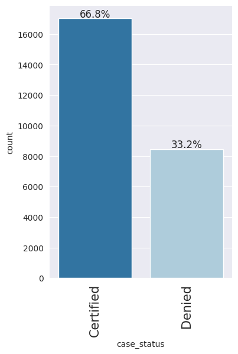

```python
labeled_barplot(viz_data, "case_status", perc=True)
```

- This is the target variable
- roughly 2/3 of the applications were certified
- seeing how this variable correlates with the ones above will be beneficial

### Observations on `education_of_employee` and `case_status`

```
case_status            Certified  Denied    All
education_of_employee
All                        17018    8462  25480
Bachelor's                  6367    3867  10234
High School                 1164    2256   3420
Master's                    7575    2059   9634
Doctorate                   1912     280   2192
------------------------------------------------------------------------------------------------------------------------
```

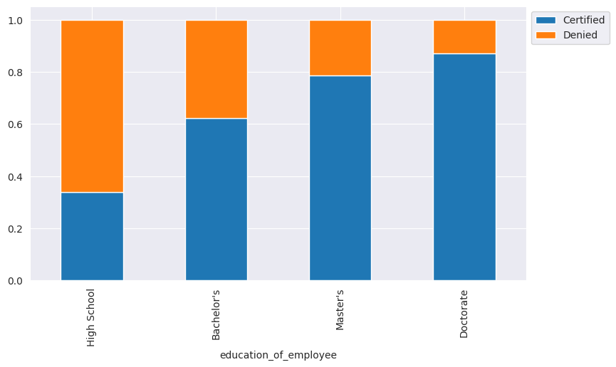

```python
#stacked barplot showing education_of_employee and case_status
stacked_barplot(viz_data, "education_of_employee", "case_status")
```

The education level of visa applicants appears to be greatly impacted by the level of education of the applicant. High School educated applicants have the highest rate of denials, while doctorate holders have the highest rate of certified status. As the level of education increases, so too does the number of approved visas.

### Observations on `has_job_experience` and `case_status`

```
case_status         Certified  Denied    All
has_job_experience
All                     17018    8462  25480
N                        5994    4684  10678
Y                       11024    3778  14802
------------------------------------------------------------------------------------------------------------------------
```

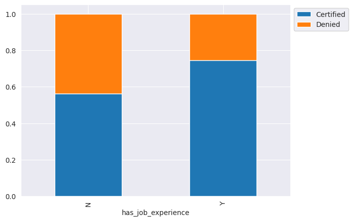

```python
#stacked bargraph on has_job_experience and case_status
stacked_barplot(viz_data, "has_job_experience", "case_status")
```

Job experience seems to play a role in the visa decision process. Applicants how have prior job experience are more likely to have their visas certified than are appliants with no prior experience.

### Observations on `prevailing_wage`

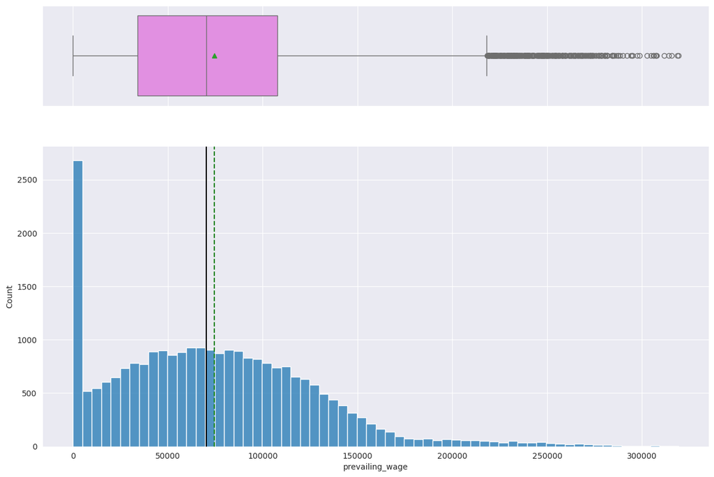

```python
histogram_boxplot(viz_data, 'prevailing_wage')
```

```python
viz_data['prevailing_wage'].describe()
```

|  | prevailing_wage |
| --- | --- |
| count | 25480.00 |
| mean | 74455.81 |
| std | 52815.94 |
| min | 2.14 |
| 25% | 34015.48 |
| 50% | 70308.21 |
| 75% | 107735.51 |
| max | 319210.27 |

**dtype:** float64

- This distribution is truly unusual. It is right skewed but with a very tall bin on the far left
- this causes the mean and median to be relatively close despite the skew
- looking at the data, this distribution is because some companies report hourly wage, while others report weekly, monthly, or yearly.
- feature engineering may be necessary to address this

### Observations on `prevailing_wage` and `case_status`

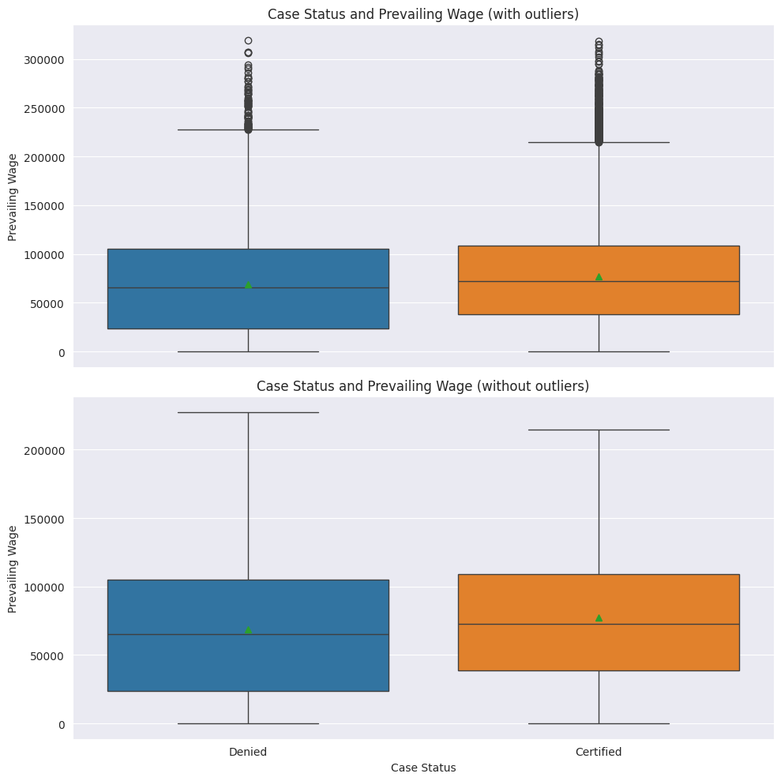

```python
fig, axes = plt.subplots(2, 1, figsize=(10, 10), sharex=True) # 2 rows, 1 column, sharing x-axis

# Subplot 1: Boxplot with outliers
sns.boxplot(data=viz_data, x='case_status', y='prevailing_wage', showmeans=True, hue='case_status', ax=axes[0], legend=False)
axes[0].set_title('Case Status and Prevailing Wage (with outliers)')
axes[0].set_xlabel('') # Remove x-label for the top plot
axes[0].set_ylabel('Prevailing Wage')
axes[0].ticklabel_format(style='plain', axis='y')

# Subplot 2: Boxplot without outliers
sns.boxplot(data=viz_data, x='case_status', y='prevailing_wage', showmeans=True, hue='case_status', showfliers=False, ax=axes[1], legend=False)
axes[1].set_title('Case Status and Prevailing Wage (without outliers)')
axes[1].set_xlabel('Case Status')
axes[1].set_ylabel('Prevailing Wage')
axes[1].ticklabel_format(style='plain', axis='y')

plt.tight_layout()
plt.show()
```

```python
#show the numeric summary of prevailing_wage grouped by case_status
viz_data.groupby("case_status")["prevailing_wage"].describe().T
```

| case_status | Certified | Denied |
| --- | --- | --- |
| count | 17018.00 | 8462.00 |
| mean | 77293.62 | 68748.68 |
| std | 52042.72 | 53890.17 |
| min | 2.14 | 2.96 |
| 25% | 38375.33 | 23497.29 |
| 50% | 72486.27 | 65431.46 |
| 75% | 108879.11 | 105097.64 |
| max | 318446.05 | 319210.27 |

I appears that both the mean and median prevailing_wage is higher for certified visa decisions. However, there is significant overlap at both the high and the low end of the scale. Without running a t.test or similar statical inference test, it is impossible to determine if these are signficantly different.

### Observations on `case_status` and `region_of_employment`

```
case_status           Certified  Denied    All
region_of_employment
All                       17018    8462  25480
Northeast                  4526    2669   7195
West                       4100    2486   6586
South                      4913    2104   7017
Midwest                    3253    1054   4307
Island                      226     149    375
------------------------------------------------------------------------------------------------------------------------
```

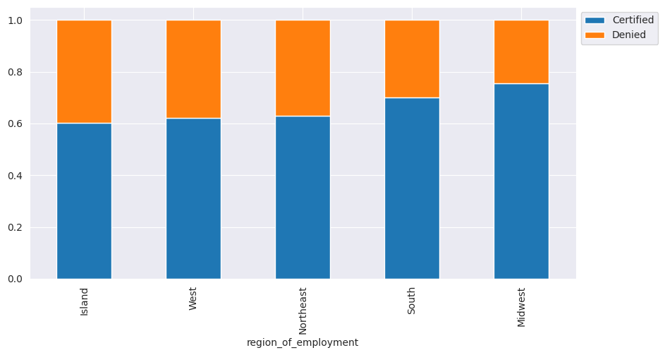

```python
#stacked bargraph of region_of_employment and case_status
stacked_barplot(viz_data, "region_of_employment", "case_status")
```

While there does not appear to be a strong difference, the south and midwest regions have a lower proportion of denied visas than the other regions do. While this is worth exploring more, a plausible explanation could be the higher need for jobs in these two less urban regions of the US.

### Observations on `case_status` and `no_of_employees`

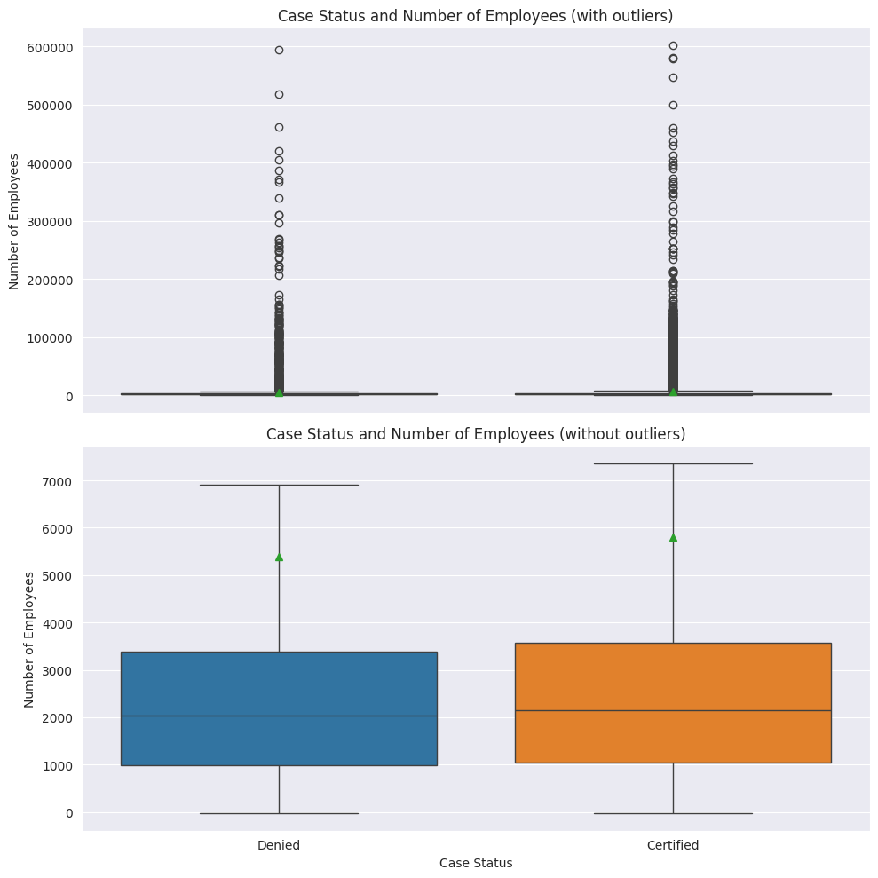

```python
fig, axes = plt.subplots(2, 1, figsize=(10, 10), sharex=True) # 2 rows, 1 column, sharing x-axis

# Subplot 1: Boxplot with outliers
sns.boxplot(data=viz_data, x='case_status', y='no_of_employees', showmeans=True, hue='case_status', ax=axes[0], legend=False)
axes[0].set_title('Case Status and Number of Employees (with outliers)')
axes[0].set_xlabel('') # Remove x-label for the top plot
axes[0].set_ylabel('Number of Employees')
axes[0].ticklabel_format(style='plain', axis='y')

# Subplot 2: Boxplot without outliers
sns.boxplot(data=viz_data, x='case_status', y='no_of_employees', showmeans=True, hue='case_status', showfliers=False, ax=axes[1], legend=False)
axes[1].set_title('Case Status and Number of Employees (without outliers)')
axes[1].set_xlabel('Case Status')
axes[1].set_ylabel('Number of Employees')
axes[1].ticklabel_format(style='plain', axis='y')

plt.tight_layout()
plt.show()
```

```python
#descriptive statistics of number of employees grouped by case_status
viz_data.groupby("case_status")["no_of_employees"].describe().T
```

| case_status | Certified | Denied |
| --- | --- | --- |
| count | 17018.00 | 8462.00 |
| mean | 5807.02 | 5385.54 |
| std | 23119.58 | 22382.76 |
| min | -26.00 | -26.00 |
| 25% | 1035.25 | 991.00 |
| 50% | 2147.00 | 2032.50 |
| 75% | 3575.00 | 3386.75 |
| max | 602069.00 | 594472.00 |

I ran this twice, once with and once without the outliers. In both cases, the size of the company, based on the number of employees, does not appear to have a significant effect on the visa decision. The one point of interest is the negative number of of employees show as the minimum in both groups. This is worth exploring in the data pre-processing stage.

### Observations on `continent` and `case_status`

```
case_status    Certified  Denied    All
continent
All                17018    8462  25480
Asia               11012    5849  16861
North America       2037    1255   3292
Europe              2957     775   3732
South America        493     359    852
Africa               397     154    551
Oceania              122      70    192
------------------------------------------------------------------------------------------------------------------------
```

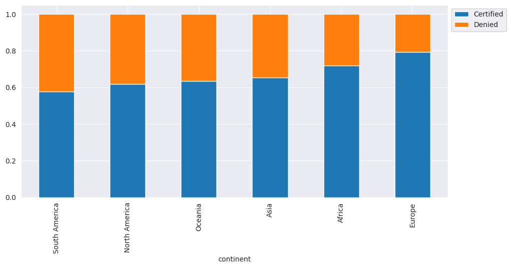

```python
#stacked bargraph of continent and case_status
stacked_barplot(viz_data, "continent", "case_status")
```

`case_status` is the target variable. South America has the highest proportion of Denied applicants. Europe has the lower proportion of denied applicants. This suggests that continent of origin may have some impact in the decision prediction.

### Observations on `unit_of_wage`

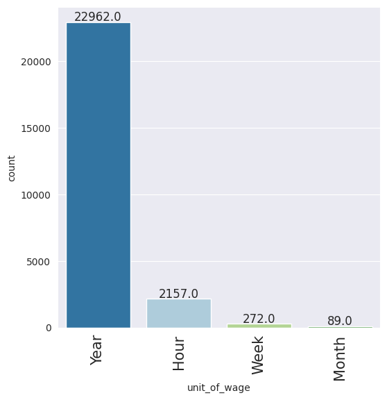

```python
labeled_barplot(viz_data, "unit_of_wage", perc=False)
```

- there appears to be a discrepancy between the unit of wage and the wage amount. This requires a deeper analysis
- most wages reported are yearly ones
- hourly wages are the second most commonly occuring one
- these discrepancies **strongly** suggest the need for feature engineering on the wage category

### Observations on `full_time_position`

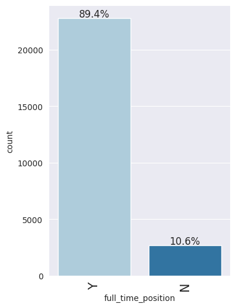

```python
labeled_barplot(viz_data, "full_time_position", perc=True)
```

- The vast majority of visa applications were for full time positions

### Observations on `prevailing_wage` and `full_time_status`

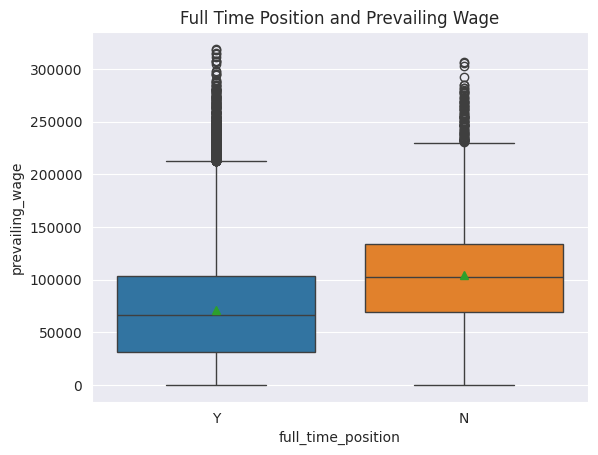

```
full_time_position         N         Y
count                2707.00  22773.00
mean               104745.40  70855.33
std                 52799.53  51651.00
min                    98.60      2.14
25%                 68947.62  30797.94
50%                102446.51  66392.67
75%                133465.05 103421.73
max                306206.67 319210.27
```

```python
#group prevailing wage by full_time_position
#calculate summary statistics and side by side boxplots
sns.boxplot(data = viz_data, x = "full_time_position", y = "prevailing_wage", showmeans = True, hue="full_time_position")
plt.title("Full Time Position and Prevailing Wage")
plt.show()
print(viz_data.groupby("full_time_position")["prevailing_wage"].describe().T)
```

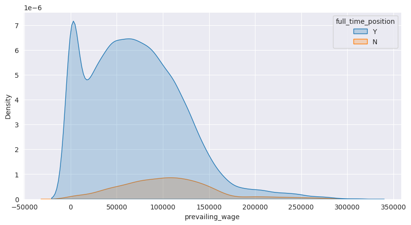

```python
#show density plot for prevailing_wage and full_time_position on a single graph
plt.figure(figsize = (10, 5))
sns.kdeplot(data = viz_data, x = "prevailing_wage", hue = "full_time_position", fill=True)
plt.show()
```

```python
#display the rows with the ten lowest prevailing_wage
viz_data.nsmallest(100, "prevailing_wage")
```

|  | case_id | continent | education_of_employee | has_job_experience | requires_job_training | no_of_employees | yr_of_estab | region_of_employment | prevailing_wage | unit_of_wage | full_time_position | case_status |
| --- | --- | --- | --- | --- | --- | --- | --- | --- | --- | --- | --- | --- |
| 20575 | EZYV20576 | North America | Master's | N | N | 1552 | 2004 | Northeast | 2.14 | Hour | Y | Certified |
| 22855 | EZYV22856 | North America | High School | Y | N | 564 | 1991 | South | 2.96 | Hour | Y | Denied |
| 17448 | EZYV17449 | South America | Master's | Y | N | 4421 | 1999 | Northeast | 3.00 | Hour | Y | Denied |
| 634 | EZYV635 | Asia | Master's | N | N | 834 | 1977 | Northeast | 3.32 | Hour | Y | Denied |
| 5455 | EZYV5456 | North America | Doctorate | Y | Y | 2038 | 2007 | Northeast | 3.49 | Hour | Y | Certified |
| ... | ... | ... | ... | ... | ... | ... | ... | ... | ... | ... | ... | ... |
| 1346 | EZYV1347 | Asia | Master's | N | N | 56 | 2001 | West | 51.68 | Hour | Y | Denied |
| 4255 | EZYV4256 | Asia | Bachelor's | N | N | 22 | 2010 | Northeast | 51.85 | Hour | Y | Denied |
| 20464 | EZYV20465 | North America | Master's | N | N | 1154 | 1977 | South | 52.05 | Hour | Y | Denied |
| 20772 | EZYV20773 | Asia | High School | N | N | 1131 | 2001 | Island | 52.82 | Hour | Y | Denied |
| 5545 | EZYV5546 | Africa | Bachelor's | N | N | 2512 | 1968 | Midwest | 52.85 | Hour | Y | Denied |

100 rows × 12 columns

There is significant overlap in the wages between full time and part time positions. Both are right skewed and the ranges are nearly identical. Oddly, the lowest wage (though not technically classifed as an outlier) of $2.1367 is from the full tiem group. This number is a bit odd since it is clearly a wage that has been adjust to show hourly (since the USA only uses cents out to the hundredths decimal place). This suggests that prevailing_wage will end up not being a very useful analysis category without feature engineering.

### Observations on `unit_of_wage` and `full_time_position`

```
full_time_position     N      Y    All
unit_of_wage
All                 2707  22773  25480
Year                2673  20289  22962
Hour                  19   2138   2157
Week                  10    262    272
Month                  5     84     89
------------------------------------------------------------------------------------------------------------------------
```

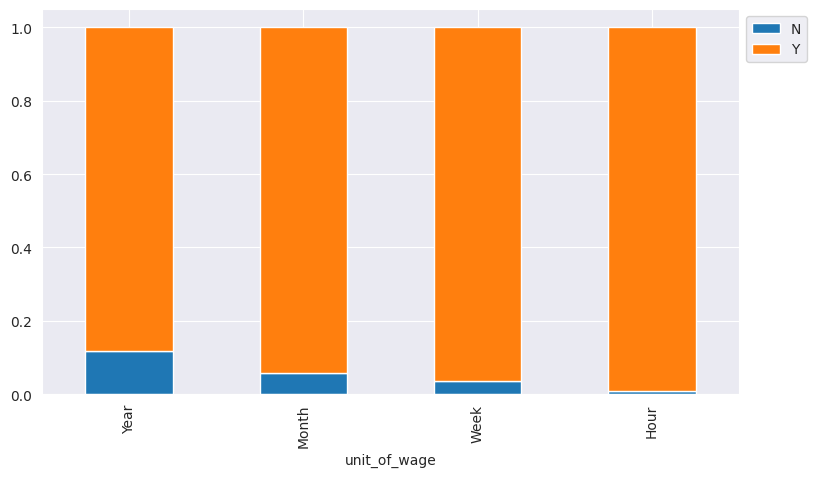

```python
#stacked barplot of unit_of_wage and full_time_position
stacked_barplot(viz_data, "unit_of_wage", "full_time_position")
```

Most applicants had full time jobs, however, for both types of position, wages were reported in a variety of units. Consolidating these units will be helpful in feature engineering.

# **Data Pre-processing**

- Missing value treatment (not needed)
- Feature engineering (if needed)
- Outlier detection and treatment (if needed)
- Preparing data for modeling
- Any other preprocessing steps (if needed)

```python
# create a copy of the data for analysis
data = df.copy()
```

### Dealing with negative employees

```python
#display the 10 rows with the fewest employees
smallest = data.nsmallest(33, "no_of_employees")
smallest
```

|  | case_id | continent | education_of_employee | has_job_experience | requires_job_training | no_of_employees | yr_of_estab | region_of_employment | prevailing_wage | unit_of_wage | full_time_position | case_status |
| --- | --- | --- | --- | --- | --- | --- | --- | --- | --- | --- | --- | --- |
| 2918 | EZYV2919 | Asia | Master's | Y | N | -26 | 2005 | Midwest | 112799.46 | Year | Y | Certified |
| 6634 | EZYV6635 | Asia | Bachelor's | Y | N | -26 | 1923 | West | 5247.32 | Year | Y | Denied |
| 7318 | EZYV7319 | Asia | Bachelor's | Y | Y | -26 | 2006 | South | 115005.61 | Year | Y | Certified |
| 9872 | EZYV9873 | Europe | Master's | Y | N | -26 | 1996 | South | 37397.05 | Year | Y | Certified |
| 14146 | EZYV14147 | Asia | Bachelor's | N | Y | -26 | 1954 | West | 81982.27 | Year | Y | Certified |
| 16883 | EZYV16884 | North America | Bachelor's | Y | N | -26 | 1968 | Northeast | 168.16 | Hour | Y | Denied |
| 17983 | EZYV17984 | Asia | Bachelor's | N | N | -26 | 2004 | South | 84359.98 | Year | Y | Denied |
| 245 | EZYV246 | Europe | Master's | N | N | -25 | 1980 | Northeast | 39452.99 | Year | Y | Certified |
| 7224 | EZYV7225 | Europe | Doctorate | N | N | -25 | 1998 | Midwest | 141435.95 | Year | Y | Certified |
| 21255 | EZYV21256 | North America | High School | N | N | -25 | 1987 | South | 99405.47 | Year | N | Denied |
| 21760 | EZYV21761 | Asia | Bachelor's | Y | N | -25 | 2000 | West | 100463.58 | Year | Y | Certified |
| 21944 | EZYV21945 | Africa | Master's | Y | N | -25 | 1977 | Midwest | 79150.51 | Year | Y | Certified |
| 832 | EZYV833 | South America | Master's | Y | N | -17 | 2002 | South | 129701.94 | Year | Y | Certified |
| 13471 | EZYV13472 | North America | Master's | N | N | -17 | 2003 | Northeast | 257.24 | Hour | Y | Denied |
| 17655 | EZYV17656 | North America | Bachelor's | Y | N | -17 | 2007 | Northeast | 129753.18 | Year | Y | Denied |
| 20815 | EZYV20816 | Asia | Bachelor's | N | Y | -17 | 1990 | West | 91897.57 | Year | Y | Certified |
| 6439 | EZYV6440 | Asia | Bachelor's | N | N | -14 | 2013 | South | 103.97 | Hour | Y | Denied |
| 7281 | EZYV7282 | Asia | High School | N | N | -14 | 2000 | Midwest | 58488.50 | Year | Y | Denied |
| 11493 | EZYV11494 | Asia | High School | Y | N | -14 | 1999 | South | 27599.35 | Year | Y | Denied |
| 15600 | EZYV15601 | Asia | Bachelor's | N | N | -14 | 2014 | South | 24641.61 | Year | Y | Denied |
| 17844 | EZYV17845 | Asia | Bachelor's | N | N | -14 | 2012 | West | 29325.85 | Year | Y | Denied |
| 20984 | EZYV20985 | Europe | Doctorate | Y | N | -14 | 1989 | Midwest | 37012.80 | Year | Y | Certified |
| 22084 | EZYV22085 | North America | Bachelor's | Y | N | -14 | 1980 | West | 691.06 | Hour | Y | Denied |
| 22388 | EZYV22389 | Asia | Master's | Y | N | -14 | 1986 | South | 17893.11 | Year | Y | Certified |
| 378 | EZYV379 | Asia | Bachelor's | N | Y | -11 | 2011 | Northeast | 32506.14 | Year | Y | Denied |
| 7761 | EZYV7762 | Asia | Master's | N | N | -11 | 2009 | Midwest | 38457.51 | Year | Y | Certified |
| 14022 | EZYV14023 | Asia | Bachelor's | N | Y | -11 | 1946 | Northeast | 108403.56 | Year | Y | Certified |
| 14726 | EZYV14727 | Asia | Master's | N | N | -11 | 2000 | Midwest | 167851.80 | Year | Y | Certified |
| 15859 | EZYV15860 | Asia | High School | N | N | -11 | 1969 | South | 44640.60 | Year | Y | Denied |
| 16157 | EZYV16158 | Asia | Master's | Y | N | -11 | 1994 | South | 62681.25 | Year | Y | Certified |
| 17006 | EZYV17007 | Asia | Doctorate | Y | N | -11 | 1984 | West | 25753.51 | Year | Y | Denied |
| 23186 | EZYV23187 | Asia | Master's | N | Y | -11 | 2007 | Midwest | 120195.35 | Year | Y | Certified |
| 23476 | EZYV23477 | Europe | Master's | Y | N | -11 | 2000 | West | 95072.75 | Year | Y | Denied |

```python
# show the number of unique values in the yr_of_establishment
smallest["yr_of_estab"].value_counts()
```

| yr_of_estab | count |
| --- | --- |
| 2000 | 4 |
| 1980 | 2 |
| 2007 | 2 |
| 2005 | 1 |
| 1996 | 1 |
| 2006 | 1 |
| 1968 | 1 |
| 1954 | 1 |
| 2004 | 1 |
| 1998 | 1 |
| 1987 | 1 |
| 1923 | 1 |
| 1977 | 1 |
| 2002 | 1 |
| 2003 | 1 |
| 1990 | 1 |
| 2013 | 1 |
| 1999 | 1 |
| 2014 | 1 |
| 2012 | 1 |
| 1989 | 1 |
| 1986 | 1 |
| 2011 | 1 |
| 2009 | 1 |
| 1946 | 1 |
| 1969 | 1 |
| 1994 | 1 |
| 1984 | 1 |

**dtype:** int64

```python
33/25480 * 100
```

```
0.12951334379905807
```

There are 33 observations out of the 25,480 observations. This accounts for 0.1295% of the data. There are three possible explanations for this value:

1. The negative was a dash indicator rather than a negative sign, in which case dropping the negative value would be best.
2. The negative sign on a 10-key pad is nearest to the 9. It is possible that each of these values should be in the 900s. However, this is less likely since companies start reporting rounded figures at roughly the 250 employee count.
3. These are pure data entry meaning they should be deleted.

```python
#drop the rows with negative values in the no_of_employees category
data = data[data["no_of_employees"] >= 0]
```

```python
# verify the drop
data.shape
```

```
(25447, 12)
```

```python
data["no_of_employees"].describe()
```

|  | no_of_employees |
| --- | --- |
| count | 25447.00 |
| mean | 5674.42 |
| std | 22891.84 |
| min | 12.00 |
| 25% | 1025.00 |
| 50% | 2112.00 |
| 75% | 3506.50 |
| max | 602069.00 |

**dtype:** float64

## Feature Engineering

### Feature Engineering on `prevailing_wage`

The goal of this code to to adjust prevailing wage into all the same unit of measure, whether yearly or annual. Since there is a relatively high number of part time positions, it only makes sense to adjust the wage to an annual rate.

```python
# 1) copy the dataframe to a new one called test_data
test_data = viz_data.copy()
```

```python
# 2) copy the prevailing_wage column to a new column titled adj_wage
test_data['adj_wage'] = test_data['prevailing_wage'].copy()

# Clean the 'unit_of_wage' column first for consistent comparisons
test_data['unit_of_wage'] = test_data['unit_of_wage'].str.strip().str.lower()

# 3) if the unit_of_wage = "hour" and if full_time_position = "Y", then multiply the corresponding value of adj_wage
# using this formula: adj_wage = adj_wage * 40 * 52 and overwrite the original value of adj_wage
test_data.loc[
    (test_data['unit_of_wage'] == 'hour') & (test_data['full_time_position'] == 'Y'),
    'adj_wage'
] = test_data['adj_wage'] * 40 * 52
test_data.loc[(test_data['unit_of_wage']== 'hour') & (test_data["full_time_position"] == 'Y'), 'unit_of_wage'] = "year"

# 4) if the unit_of_wage = "week" then multiply using the formula: adj_wage = adj_wage * 52
test_data.loc[(test_data['unit_of_wage'] == 'week'),'adj_wage'] = test_data['adj_wage'] * 52
test_data.loc[(test_data['unit_of_wage']== 'week'), 'unit_of_wage'] = "year"

# 5) if the unit_of_wage = "month"  then use the formula adj_wage = adj_wage * 12
test_data.loc[(test_data['unit_of_wage'] == 'month'),'adj_wage'] = test_data['adj_wage'] * 12
test_data.loc[(test_data['unit_of_wage']== 'month'), 'unit_of_wage'] = "year"


display(test_data.head())
```

|  | case_id | continent | education_of_employee | has_job_experience | requires_job_training | no_of_employees | yr_of_estab | region_of_employment | prevailing_wage | unit_of_wage | full_time_position | case_status | adj_wage |
| --- | --- | --- | --- | --- | --- | --- | --- | --- | --- | --- | --- | --- | --- |
| 0 | EZYV01 | Asia | High School | N | N | 14513 | 2007 | West | 592.20 | year | Y | Denied | 1231782.03 |
| 1 | EZYV02 | Asia | Master's | Y | N | 2412 | 2002 | Northeast | 83425.65 | year | Y | Certified | 83425.65 |
| 2 | EZYV03 | Asia | Bachelor's | N | Y | 44444 | 2008 | West | 122996.86 | year | Y | Denied | 122996.86 |
| 3 | EZYV04 | Asia | Bachelor's | N | N | 98 | 1897 | West | 83434.03 | year | Y | Denied | 83434.03 |
| 4 | EZYV05 | Africa | Master's | Y | N | 1082 | 2005 | South | 149907.39 | year | Y | Certified | 149907.39 |

```
full_time_position     N      Y    All
unit_of_wage
All                 2707  22773  25480
year                2688  22773  25461
hour                  19      0     19
------------------------------------------------------------------------------------------------------------------------
```

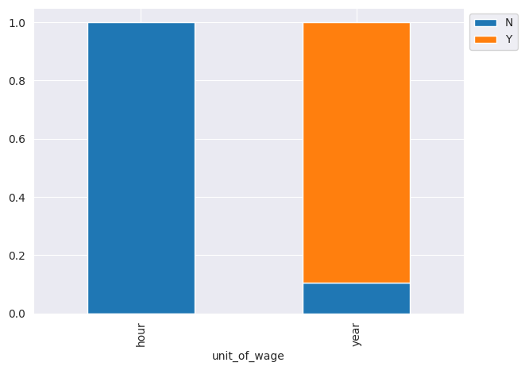

```python
#display a stacked barchart of unit_of_wage and full_time_status
stacked_barplot(test_data, "unit_of_wage", "full_time_position")
```

There are still 19 positions are are labeled as hourly and and part-time. Since the number of hours on offer are not included in this data set, and since 19 is a relatively small proportion of the data set, the decision has been made to drop these values.

```python
#drop the 19 rows that have a unit_of_wage of an hour
test_data = test_data[test_data["unit_of_wage"] != "hour"]
```

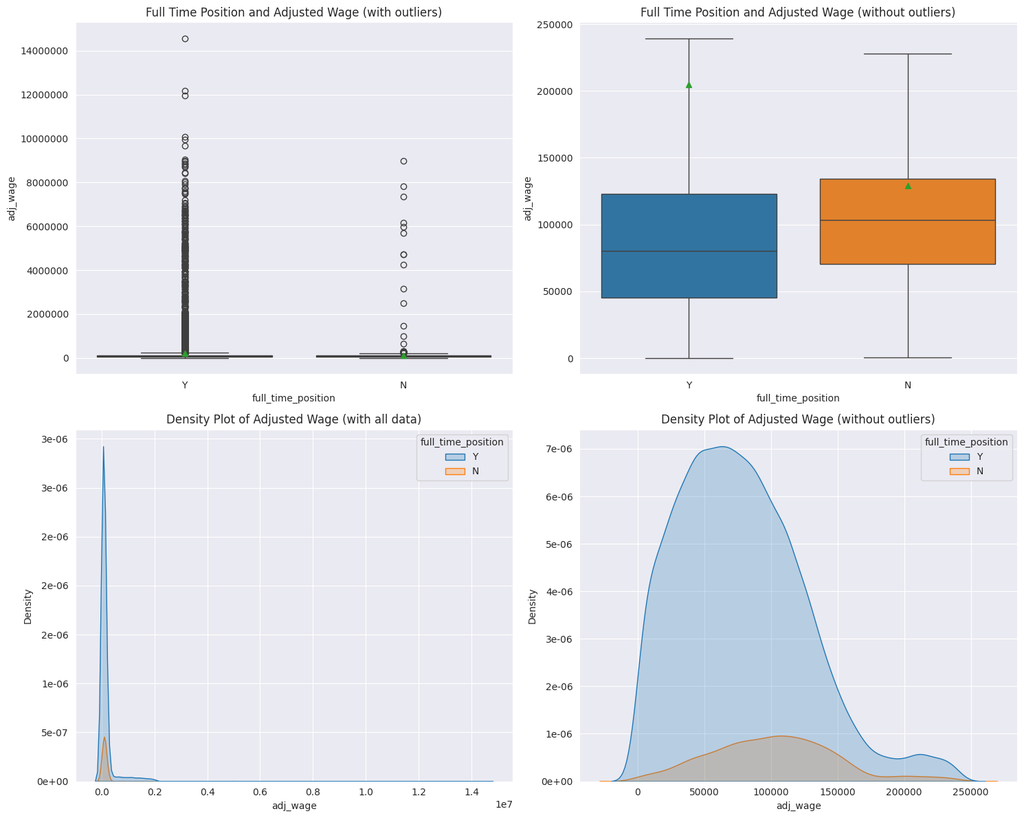

```python
# Create a 2x2 grid of subplots
fig, axes = plt.subplots(2, 2, figsize=(15, 12))

# First subplot (top-left): original boxplot with no scientific notation and integer display
sns.boxplot(data=test_data, x="full_time_position", y="adj_wage", showmeans=True, hue="full_time_position", ax=axes[0, 0], legend=False)
axes[0, 0].set_title("Full Time Position and Adjusted Wage (with outliers)")
axes[0, 0].yaxis.set_major_formatter(mticker.FormatStrFormatter('%d'))

# Second subplot (top-right): boxplot without outliers, no scientific notation, and integer display
sns.boxplot(data=test_data, x="full_time_position", y="adj_wage", showmeans=True, hue="full_time_position", showfliers=False, ax=axes[0, 1], legend=False)
axes[0, 1].set_title("Full Time Position and Adjusted Wage (without outliers)")
axes[0, 1].yaxis.set_major_formatter(mticker.FormatStrFormatter('%d'))

# Third subplot (bottom-left): KDE plot corresponding to the first boxplot
sns.kdeplot(data=test_data, x="adj_wage", hue="full_time_position", fill=True, ax=axes[1, 0])
axes[1, 0].set_title("Density Plot of Adjusted Wage (with all data)")
axes[1, 0].yaxis.set_major_formatter(mticker.FormatStrFormatter('%.0e')) # scientific for density as it's small

# Fourth subplot (bottom-right): KDE plot for data without outliers
# Filter test_data to remove outliers based on the same logic used for viz_data_trimmed earlier,
# or re-calculate for test_data if 'adj_wage' has different outlier characteristics.
# For now, let's assume we want to show the KDE for the original data to match the first boxplot, or filter the outliers here.
# A more robust approach might re-calculate IQR for 'adj_wage' in test_data.

# Calculate IQR for 'adj_wage' in test_data for accurate outlier removal for the KDE plot
Q1_adj = test_data['adj_wage'].quantile(0.25)
Q3_adj = test_data['adj_wage'].quantile(0.75)
IQR_adj = Q3_adj - Q1_adj
lower_bound_adj = Q1_adj - 1.5 * IQR_adj
upper_bound_adj = Q3_adj + 1.5 * IQR_adj

test_data_trimmed_adj = test_data[(test_data['adj_wage'] >= lower_bound_adj) & (test_data['adj_wage'] <= upper_bound_adj)]

sns.kdeplot(data=test_data_trimmed_adj, x="adj_wage", hue="full_time_position", fill=True, ax=axes[1, 1])
axes[1, 1].set_title("Density Plot of Adjusted Wage (without outliers)")
axes[1, 1].yaxis.set_major_formatter(mticker.FormatStrFormatter('%.0e'))

plt.tight_layout()
plt.show()
```

```python
test_data["adj_wage"].describe()
```

|  | adj_wage |
| --- | --- |
| count | 25461.00 |
| mean | 196780.27 |
| std | 578152.22 |
| min | 100.00 |
| 25% | 47093.10 |
| 50% | 82797.00 |
| 75% | 124682.81 |
| max | 14569149.40 |

**dtype:** float64

```python
#display a count of the number of adj_wage values that are less than $30000
count_less_than_30k = test_data[test_data['adj_wage'] < 30000].shape[0]
count_less_than_20k = test_data[test_data['adj_wage'] < 20000].shape[0]
count_less_than_10k = test_data[test_data['adj_wage'] < 10000].shape[0]
print(f"Number of 'adj_wage' values less than $30,000: {count_less_than_30k}")
print(f"Number of 'adj_wage' values less than $20,000: {count_less_than_20k}")
print(f"Number of 'adj_wage' values less than $10,000: {count_less_than_10k}")
```

```
Number of 'adj_wage' values less than $30,000: 3561
Number of 'adj_wage' values less than $20,000: 2192
Number of 'adj_wage' values less than $10,000: 1043
```

Having worked overseas myself, I know that there is often a minimal salary threshhold for obtaining a post. As a result, many of the lower values in the adjusted wage category seem suspect (such as the $99.999 annual wage). The confusion may have resulted from the fact that the USA uses a comma (,) to separate groups of thousands while other countries use periods (.) for this same principle. However, there are a very high number of adj_wage values that are less than $30,000. without more information, any more adjustment to this column would be arbitrary. There is too much data to drop. As a result, these values, though odd, will remain. However, in order to reduce the granularity of the data, I will group the adjusted wage into five categorical variables using quantiles.

### Feature engineering - year established

The year established (1800 to 2016) might not be the best way to view these categories since older companies would have a lower value. As a result, I will create a new category called yrs_in_bus by subtracting the founding year from 2016 (the most recent year in the dataset).

```python
test_data["yrs_in_bus"] = 2016 - test_data["yr_of_estab"]
test_data["yrs_in_bus"].describe()
```

|  | yrs_in_bus |
| --- | --- |
| count | 25461.00 |
| mean | 36.58 |
| std | 42.36 |
| min | 0.00 |
| 25% | 11.00 |
| 50% | 19.00 |
| 75% | 40.00 |
| max | 216.00 |

**dtype:** float64

### Feature engineering - wage categories

```python
# Define the new categories
new_categories = ["very low", "below average", "average", "above average", "very high"]

# Create a CategoricalDtype object with the desired categories and order
wage_cat_dtype = pd.CategoricalDtype(categories=new_categories, ordered=True)

# using the adj_wage, split it into 5 categories with explicit labels and dtype
test_data.loc[:, "wage_category"] = pd.qcut(
    test_data["adj_wage"], 5, labels=new_categories
).astype(wage_cat_dtype)

test_data["wage_category"].value_counts()
```

| wage_category | count |
| --- | --- |
| very low | 5093 |
| below average | 5092 |
| average | 5092 |
| above average | 5092 |
| very high | 5092 |

**dtype:** int64

```python
#view current data frame
test_data.head()
```

|  | case_id | continent | education_of_employee | has_job_experience | requires_job_training | no_of_employees | yr_of_estab | region_of_employment | prevailing_wage | unit_of_wage | full_time_position | case_status | adj_wage | yrs_in_bus | wage_category |
| --- | --- | --- | --- | --- | --- | --- | --- | --- | --- | --- | --- | --- | --- | --- | --- |
| 0 | EZYV01 | Asia | High School | N | N | 14513 | 2007 | West | 592.20 | year | Y | Denied | 1231782.03 | 9 | very high |
| 1 | EZYV02 | Asia | Master's | Y | N | 2412 | 2002 | Northeast | 83425.65 | year | Y | Certified | 83425.65 | 14 | average |
| 2 | EZYV03 | Asia | Bachelor's | N | Y | 44444 | 2008 | West | 122996.86 | year | Y | Denied | 122996.86 | 8 | above average |
| 3 | EZYV04 | Asia | Bachelor's | N | N | 98 | 1897 | West | 83434.03 | year | Y | Denied | 83434.03 | 119 | average |
| 4 | EZYV05 | Africa | Master's | Y | N | 1082 | 2005 | South | 149907.39 | year | Y | Certified | 149907.39 | 11 | very high |

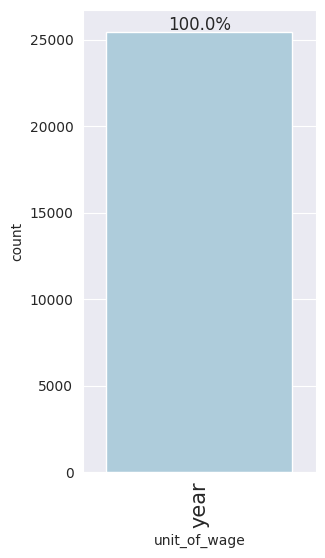

```python
#barplot for unit_of_wage
labeled_barplot(test_data, "unit_of_wage", perc=True)
```

### Observations on Correlation Matrix

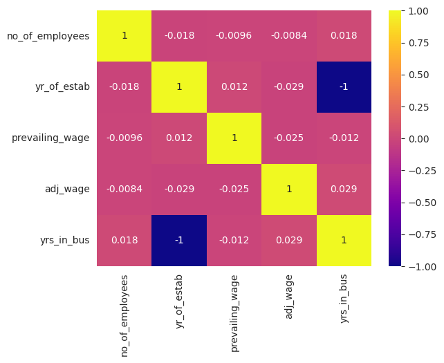

```python
#create a correlation matrix of numeric values

corr_matrix = test_data.corr(numeric_only = True)

#create a heatmap visualization for the correlation matrix

sns.heatmap(corr_matrix, cmap = "plasma", annot = True)
```

There is virtually no correlation between any of the numeric values. There is a lack of correlation between adjusted wage and prevailing wage; however, due to the different units reported for the wage, this is not wholely unexpected. As a result of this feature engineering, prevailing_wage and unit_of_wage can be dropped. Not surprising, there is a perfectly negative correlation between yrs_in_bus and yr_of_estab, so one of these will be dropped.

## Outlier Treatment

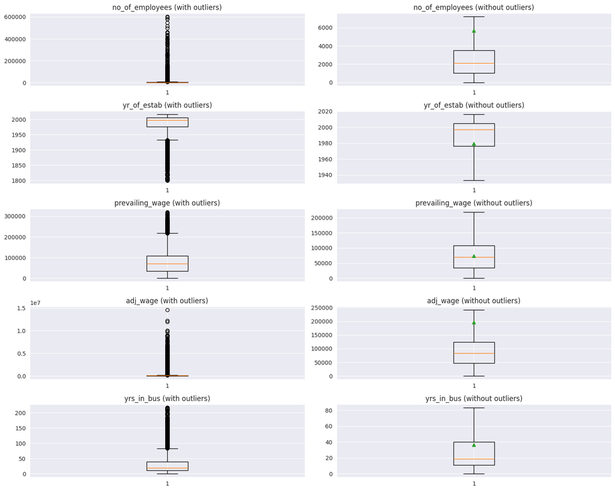

```python
import numpy as np
import matplotlib.pyplot as plt

# use a loop to display boxplots for all the numeric variable in the test_data data frame
numeric_columns = test_data.select_dtypes(include=np.number).columns.tolist()

plt.figure(figsize=(15, 12))

plot_idx = 1 # Initialize a counter for subplot positions

for variable in numeric_columns:
    # Plot with outliers
    ax1 = plt.subplot(5, 2, plot_idx) # Changed from 4 to 5 rows
    ax1.boxplot(test_data[variable], whis=1.5)
    ax1.set_title(f'{variable} (with outliers)')
    plot_idx += 1

    # Plot without outliers
    ax2 = plt.subplot(5, 2, plot_idx) # Changed from 4 to 5 rows
    ax2.boxplot(test_data[variable], whis=1.5, showfliers=False, showmeans=True)
    ax2.set_title(f'{variable} (without outliers)')
    plot_idx += 1

plt.tight_layout() # Call tight_layout once after all subplots are created
plt.show()
```

### Dropping unnecessary categories

```python
#drop case_ID, prevailing_wage, and unit_of_wage from test_data
test_data = test_data.drop(columns = ["case_id", "prevailing_wage", "unit_of_wage", "yr_of_estab"])
```

```python
data1 = test_data.copy()
data1.head()
```

|  | continent | education_of_employee | has_job_experience | requires_job_training | no_of_employees | region_of_employment | full_time_position | case_status | adj_wage | yrs_in_bus | wage_category |
| --- | --- | --- | --- | --- | --- | --- | --- | --- | --- | --- | --- |
| 0 | Asia | High School | N | N | 14513 | West | Y | Denied | 1231782.03 | 9 | very high |
| 1 | Asia | Master's | Y | N | 2412 | Northeast | Y | Certified | 83425.65 | 14 | average |
| 2 | Asia | Bachelor's | N | Y | 44444 | West | Y | Denied | 122996.86 | 8 | above average |
| 3 | Asia | Bachelor's | N | N | 98 | West | Y | Denied | 83434.03 | 119 | average |
| 4 | Africa | Master's | Y | N | 1082 | South | Y | Certified | 149907.39 | 11 | very high |

## EDA for Engineered Features

### Observations on `adj_wage` and `case_status`

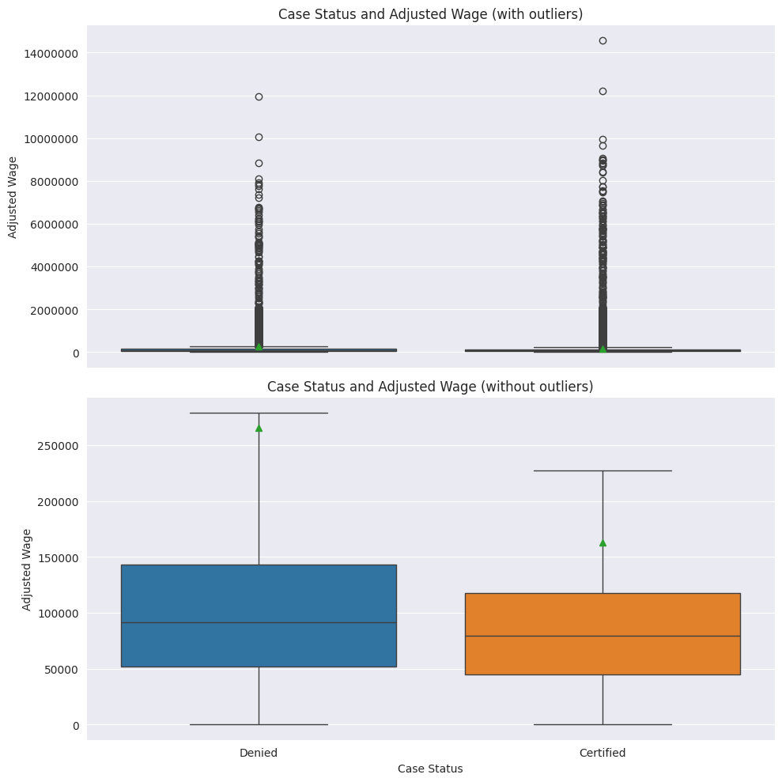

```python
# Boxplots for adj_wage and case_status
fig, axes = plt.subplots(2, 1, figsize=(10, 10), sharex=True) # 2 rows, 1 column, sharing x-axis

# Subplot 1: Boxplot with outliers
sns.boxplot(data=data1, x='case_status', y='adj_wage', showmeans=True, hue='case_status', ax=axes[0], legend=False)
axes[0].set_title('Case Status and Adjusted Wage (with outliers)')
axes[0].set_xlabel('') # Remove x-label for the top plot
axes[0].set_ylabel('Adjusted Wage')
axes[0].ticklabel_format(style='plain', axis='y')

# Subplot 2: Boxplot without outliers
sns.boxplot(data=data1, x='case_status', y='adj_wage', showmeans=True, hue='case_status', showfliers=False, ax=axes[1], legend=False)
axes[1].set_title('Case Status and Adjusted Wage (without outliers)')
axes[1].set_xlabel('Case Status')
axes[1].set_ylabel('Adjusted Wage')
axes[1].ticklabel_format(style='plain', axis='y')

plt.tight_layout()
plt.show()
```

### Observations on `case_status`, `full_time_position` and `wage_category`

Knowing that there is a strong relationship between full time jobs and wages, this section will attempt to visualize the three way relationship between job type, wage cateorgy, and visa outcome.

```
full_time_position     N      Y    All
wage_category
All                 2688  22773  25461
above average        845   4247   5092
very high            621   4471   5092
average              571   4521   5092
below average        411   4681   5092
very low             240   4853   5093
------------------------------------------------------------------------------------------------------------------------
```

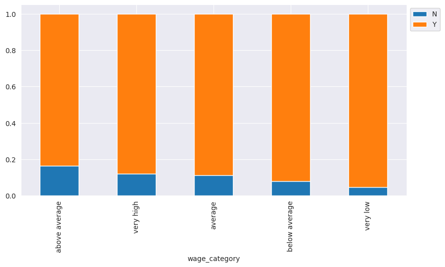

```python
#stacked barplot for wage_categry and full_time_position
stacked_barplot(data1, "wage_category", "full_time_position")
```

Wages that are coded as above average and high have an unusally large number of part-time jobs listed.

```
case_status    Certified  Denied    All
wage_category
All                17015    8446  25461
very high           2834    2258   5092
above average       3453    1639   5092
average             3507    1585   5092
below average       3575    1517   5092
very low            3646    1447   5093
------------------------------------------------------------------------------------------------------------------------
```

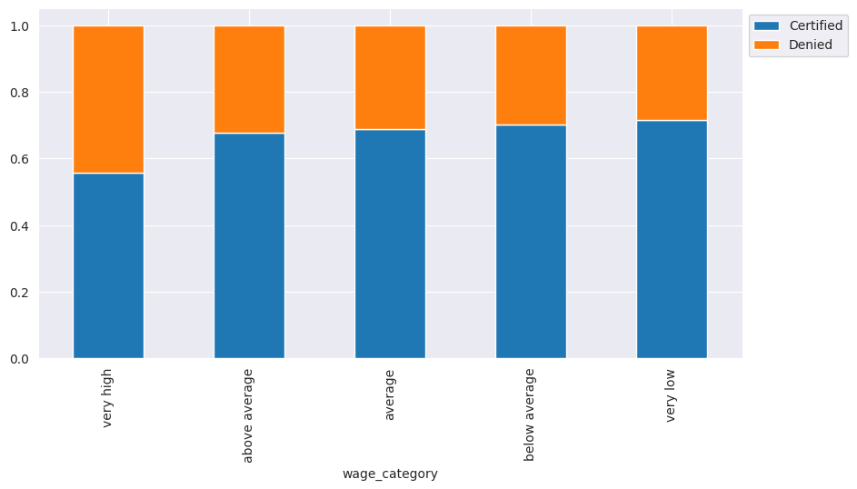

```python
#stacked barplot for case_status and wage_category
stacked_barplot(data1, "wage_category", "case_status")
```

Interestingly, the high wage category has the highest number of cases denied. The other four wage categories are visiually equivalent.

### Observations on `case_status`, `full_time_position`, and `wage_category`

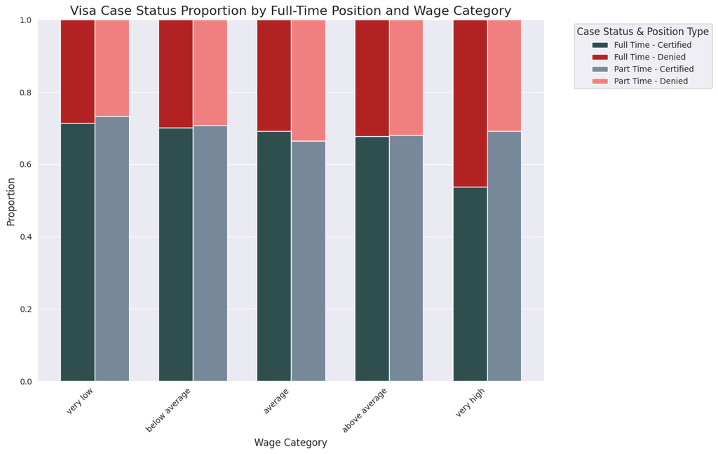

```python
# Ensure 'wage_category', 'full_time_position', and 'case_status' are categorical
# 'wage_category' is already ordered from previous steps.
if not isinstance(data1['full_time_position'].dtype, pd.CategoricalDtype):
    data1['full_time_position'] = data1['full_time_position'].astype('category')
if not isinstance(data1['case_status'].dtype, pd.CategoricalDtype):
    data1['case_status'] = data1['case_status'].astype('category')

# Create a mapping for full_time_position labels (Y/N to Full Time/Part Time)
position_map = {
    'Y': 'Full Time',
    'N': 'Part Time'
}
data1['full_time_position_label'] = data1['full_time_position'].map(position_map).astype('category')

# Group data to get counts for each combination of wage_category, full_time_position_label, and case_status
plot_df_counts = data1.groupby(['wage_category', 'full_time_position_label', 'case_status'], observed=True).size().unstack(level='case_status').fillna(0)

# Calculate proportions within each full_time_position_label for each wage_category
# This makes each 'Full Time' bar sum to 1 and each 'Part Time' bar sum to 1
# Corrected calculation for plot_df to properly normalize proportions
plot_df = plot_df_counts.div(plot_df_counts.sum(axis=1), axis=0)

# Define a darker color scheme for better readability as requested previously
colors = {
    ('Full Time', 'Certified'): 'darkslategray',
    ('Full Time', 'Denied'): 'firebrick',
    ('Part Time', 'Certified'): 'lightslategray',
    ('Part Time', 'Denied'): 'lightcoral'
}

# Get ordered wage categories from the DataFrame's categorical dtype
wage_categories_ordered = data1['wage_category'].cat.categories.tolist()

fig, ax = plt.subplots(figsize=(15, 8))

# Position of each group of bars on the x-axis
ind = np.arange(len(wage_categories_ordered))
width = 0.35 # Width of the bars for Full Time/Part Time

for i, category in enumerate(wage_categories_ordered):
    # Get data for 'Full Time' and 'Part Time' for the current wage category
    # Use .get() with a default empty Series to handle cases where a combination might not exist after proportion calculation
    full_time_data = plot_df.loc[(category, 'Full Time')] if (category, 'Full Time') in plot_df.index else pd.Series({'Certified': 0, 'Denied': 0})
    part_time_data = plot_df.loc[(category, 'Part Time')] if (category, 'Part Time') in plot_df.index else pd.Series({'Certified': 0, 'Denied': 0})

    # Plot 'Full Time' bars (Certified and Denied stacked)
    bottom_full_time = 0
    if 'Certified' in full_time_data.index and full_time_data['Certified'] > 0:
        ax.bar(ind[i] - width/2, full_time_data['Certified'], width,
               bottom=bottom_full_time,
               label='Full Time - Certified' if i == 0 else "", # Label only once for legend
               color=colors[('Full Time', 'Certified')], edgecolor='white')
        bottom_full_time += full_time_data['Certified']
    if 'Denied' in full_time_data.index and full_time_data['Denied'] > 0:
        ax.bar(ind[i] - width/2, full_time_data['Denied'], width,
               bottom=bottom_full_time,
               label='Full Time - Denied' if i == 0 else "", # Label only once for legend
               color=colors[('Full Time', 'Denied')], edgecolor='white')

    # Plot 'Part Time' bars (Certified and Denied stacked)
    bottom_part_time = 0
    if 'Certified' in part_time_data.index and part_time_data['Certified'] > 0:
        ax.bar(ind[i] + width/2, part_time_data['Certified'], width,
               bottom=bottom_part_time,
               label='Part Time - Certified' if i == 0 else "", # Label only once for legend
               color=colors[('Part Time', 'Certified')], edgecolor='white')
        bottom_part_time += part_time_data['Certified']
    if 'Denied' in part_time_data.index and part_time_data['Denied'] > 0:
        ax.bar(ind[i] + width/2, part_time_data['Denied'], width,
               bottom=bottom_part_time,
               label='Part Time - Denied' if i == 0 else "", # Label only once for legend
               color=colors[('Part Time', 'Denied')], edgecolor='white')

ax.set_ylabel('Proportion', fontsize=12)
ax.set_xlabel('Wage Category', fontsize=12)
ax.set_title('Visa Case Status Proportion by Full-Time Position and Wage Category', fontsize=16)
ax.set_xticks(ind)
ax.set_xticklabels(wage_categories_ordered, rotation=45, ha='right', fontsize=10)
ax.tick_params(axis='y', labelsize=10)
ax.set_ylim(0, 1) # Set y-axis limit for proportions from 0 to 1

# Create a custom legend using Patch objects
legend_patches = [
    Patch(facecolor=colors[('Full Time', 'Certified')], label='Full Time - Certified'),
    Patch(facecolor=colors[('Full Time', 'Denied')], label='Full Time - Denied'),
    Patch(facecolor=colors[('Part Time', 'Certified')], label='Part Time - Certified'),
    Patch(facecolor=colors[('Part Time', 'Denied')], label='Part Time - Denied')
]
ax.legend(handles=legend_patches, title="Case Status & Position Type", bbox_to_anchor=(1.05, 1), loc='upper left', fontsize=10, title_fontsize=12)

plt.tight_layout(rect=[0, 0, 0.85, 1]) # Adjust rect to make space for the legend
plt.show()
```

### Observations on `case_status`, `adj_wage`, and `full_time_position`

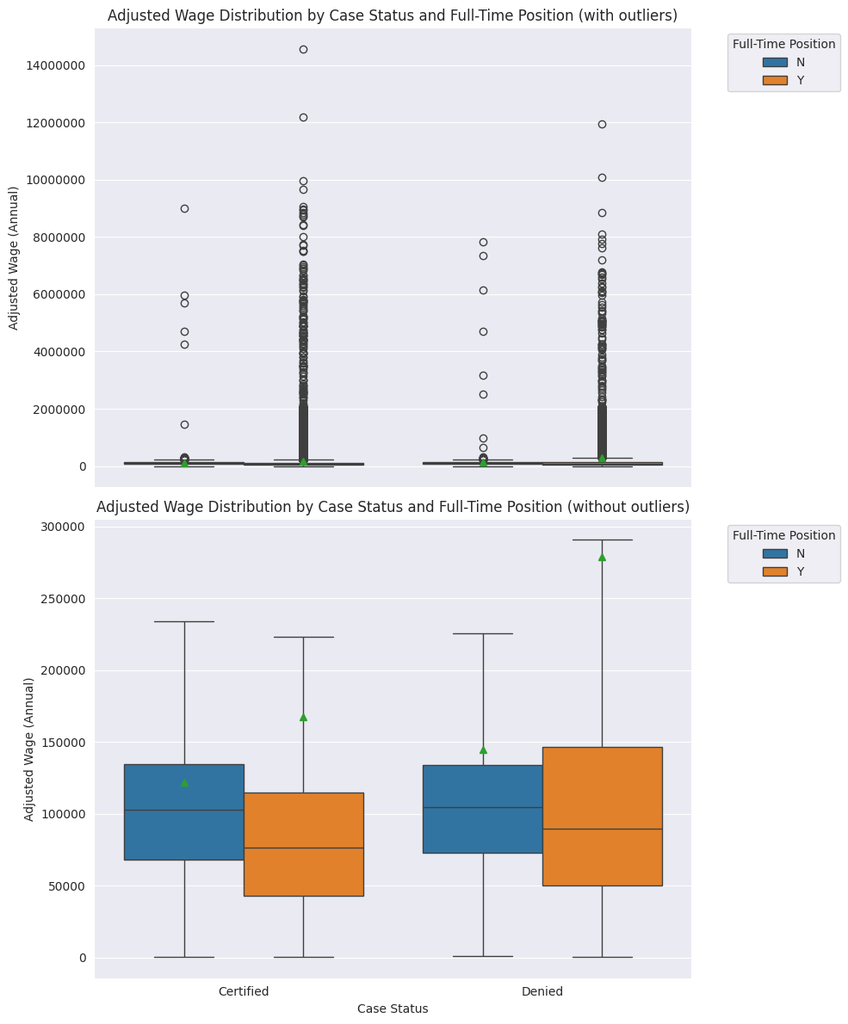

```python
# Create a figure with two subplots (2 rows, 1 column) for vertical arrangement
fig, axes = plt.subplots(2, 1, figsize=(10, 12), sharex=True) # sharex ensures x-axis scale is consistent, figsize adjusted for vertical

# Subplot 1 (top): Boxplot with outliers
sns.boxplot(data=data1, x='case_status', y='adj_wage', hue='full_time_position', showmeans=True, ax=axes[0])
axes[0].set_title('Adjusted Wage Distribution by Case Status and Full-Time Position (with outliers)')
axes[0].set_xlabel('') # Remove x-label for top plot as it's shared and will be on the bottom plot
axes[0].set_ylabel('Adjusted Wage (Annual)')
axes[0].ticklabel_format(style='plain', axis='y') # Disable scientific notation for y-axis
axes[0].legend(title='Full-Time Position', bbox_to_anchor=(1.05, 1), loc='upper left')

# Subplot 2 (bottom): Boxplot without outliers
sns.boxplot(data=data1, x='case_status', y='adj_wage', hue='full_time_position', showmeans=True, showfliers=False, ax=axes[1])
axes[1].set_title('Adjusted Wage Distribution by Case Status and Full-Time Position (without outliers)')
axes[1].set_xlabel('Case Status') # Keep x-label for the bottom plot
axes[1].set_ylabel('Adjusted Wage (Annual)') # Keep y-label as it's a new row
axes[1].ticklabel_format(style='plain', axis='y') # Disable scientific notation for y-axis
axes[1].legend(title='Full-Time Position', bbox_to_anchor=(1.05, 1), loc='upper left')

plt.tight_layout()
plt.show()
```

### Data Preparation for Modeling

```python
data1["case_status"] = data1["case_status"].apply(lambda x: 1 if x == "Certified" else 0)

X = data1.drop(["case_status"], axis=1)
y = data1["case_status"]


X = pd.get_dummies(X, drop_first=True)
# X = X.astype(float)

# Splitting data into training, validation and test set:
# first split data into 2 parts,  temporary and test

X_temp, X_test, y_temp, y_test = train_test_split(
    X, y, test_size=0.2, random_state=1, stratify=y
)

# then  split the temporary set into train and validation

X_train, X_val, y_train, y_val = train_test_split(
    X_temp, y_temp, test_size=0.25, random_state=1, stratify=y_temp
)
```

```python
print("Shape of Training set : ", X_train.shape)
print("Shape of the Validation set: ", X_val.shape)
print("Shape of test set : ", X_test.shape)
print("Percentage of classes in training set:")
print(y_train.value_counts(normalize=True))
print("Percentage of classes in validation set:")
print(y_val.value_counts(normalize=True))
print("Percentage of classes in test set:")
print(y_test.value_counts(normalize=True))
```

```
Shape of Training set :  (15276, 23)
Shape of the Validation set:  (5092, 23)
Shape of test set :  (5093, 23)
Percentage of classes in training set:
case_status
1   0.67
0   0.33
Name: proportion, dtype: float64
Percentage of classes in validation set:
case_status
1   0.67
0   0.33
Name: proportion, dtype: float64
Percentage of classes in test set:
case_status
1   0.67
0   0.33
Name: proportion, dtype: float64
```

The splits appear to have correctly captured the right proportions of the target variable.

# **Model Building**

### **Model evaluation criterion**

The model can make wrong predictions as:

1. Model predicts that the visa application will get certified but in reality, the visa application should get denied.
2. Model predicts that the visa application will not get certified but in reality, the visa application should get certified.

**Which case is more important?**

In this context, both of the cases are important:

1. If a visa is certified when it had to be denied a wrong employee will get the job position while US citizens will miss the opportunity to work on that position.
2. However, if a visa is denied when it had to be certified the U.S. will lose a suitable human resource that can contribute to the economy.

**How to reduce the losses?**

I will be using *F1 Score*: the greater the F1 score higher are the chances of minimizing both False Negatives and False Positives. We will use balanced class weights so that model focuses equally on both classes.

```python
#custom functions for model comparison taken from the course

def model_performance_classification_sklearn(model, predictors, target):
    """
    Function to compute different metrics to check classification model performance

    model: classifier
    predictors: independent variables
    target: dependent variable
    """

    # predicting using the independent variables
    pred = model.predict(predictors)

    acc = accuracy_score(target, pred)  # to compute Accuracy
    recall = recall_score(target, pred)  # to compute Recall
    precision = precision_score(target, pred)  # to compute Precision
    f1 = f1_score(target, pred)  # to compute F1-score

    # creating a dataframe of metrics
    df_perf = pd.DataFrame(
        {"Accuracy": acc, "Recall": recall, "Precision": precision, "F1": f1,},
        index=[0],
    )

    return df_perf

def confusion_matrix_sklearn(model, predictors, target):
    """
    To plot the confusion_matrix with percentages

    model: classifier
    predictors: independent variables
    target: dependent variable
    """
    y_pred = model.predict(predictors)
    cm = confusion_matrix(target, y_pred)
    labels = np.asarray(
        [
            ["{0:0.0f}".format(item) + "\n{0:.2%}".format(item / cm.flatten().sum())]
            for item in cm.flatten()
        ]
    ).reshape(2, 2)

    plt.figure(figsize=(6, 4))
    sns.heatmap(cm, annot=labels, fmt="")
    plt.ylabel("True label")
    plt.xlabel("Predicted label")
```

### First Model with Data

```python
models = []  # Empty list to store all the models

# Appending models into the list
models.append(("Bagging", BaggingClassifier(random_state=1)))
models.append(("Random Forest", RandomForestClassifier(random_state=1, class_weight="balanced")))
models.append(("AdaBoost", AdaBoostClassifier(random_state=1)))
models.append(("Gradient Boosting", GradientBoostingClassifier(random_state=1)))
models.append(("XGBoost", XGBClassifier(random_state=1, eval_metric='logloss', use_label_encoder=False)))

print("\n" "Training Performance:" "\n")
for name, model in models:
    model.fit(X_train, y_train)
    scores = f1_score(y_train, model.predict(X_train))
    print("{}: {}".format(name, scores))

print("\n" "Validation Performance:" "\n")

for name, model in models:
    model.fit(X_train, y_train)
    scores_val = f1_score(y_val, model.predict(X_val))
    print("{}: {}".format(name, scores_val))
```

```
Training Performance:

Bagging: 0.9881081081081081
Random Forest: 1.0
AdaBoost: 0.8153901409715363
Gradient Boosting: 0.8248117869844349
XGBoost: 0.8955558670965933

Validation Performance:

Bagging: 0.7708333333333334
Random Forest: 0.7959838237344862
AdaBoost: 0.8130715438407746
Gradient Boosting: 0.8191107428887048
XGBoost: 0.8057373624843337
```

Using the original data, we have the expected overfitting with both Bagging and Random Forest. As it stands, AdaBoost and Gradient Boosting both have very similar F! scores. While it is important to tune the models, this is a good sign, especially considering the high starting point for these scores. XGBoost is overfitting a little bit, but not as much as bagging and random forest.

### Model Building with Oversampled Data

```python
print("Before Oversampling, counts of label 'Certified': {}".format(sum(y_train == 1)))
print("Before Oversampling, counts of label 'Denied': {} \n".format(sum(y_train == 0)))

sm = SMOTE(
    sampling_strategy=1, k_neighbors=5, random_state=1
)  # Synthetic Minority Over Sampling Technique
X_train_over, y_train_over = sm.fit_resample(X_train, y_train)


print("After Oversampling, counts of label 'Certified': {}".format(sum(y_train_over == 1)))
print("After Oversampling, counts of label 'Denied': {} \n".format(sum(y_train_over == 0)))


print("After Oversampling, the shape of X_train_over: {}".format(X_train_over.shape))
print("After Oversampling, the shape of y_train_over: {} \n".format(y_train_over.shape))
```

```
Before Oversampling, counts of label 'Certified': 10208
Before Oversampling, counts of label 'Denied': 5068

After Oversampling, counts of label 'Certified': 10208
After Oversampling, counts of label 'Denied': 10208

After Oversampling, the shape of X_train_over: (20416, 23)
After Oversampling, the shape of y_train_over: (20416,)
```

```python
models = []  # Empty list to store all the models

# Appending models into the list
models.append(("Bagging", BaggingClassifier(random_state=1)))
models.append(("Random Forest", RandomForestClassifier(random_state=1)))
models.append(("AdaBoost", AdaBoostClassifier(random_state=1)))
models.append(("Gradient Boosting", GradientBoostingClassifier(random_state=1)))
models.append(("XGBoost", XGBClassifier(random_state=1, eval_metric='logloss', use_label_encoder=False)))

print("\n" "Training Performance:" "\n")
for name, model in models:
    model.fit(X_train_over, y_train_over)
    scores = f1_score(y_train_over, model.predict(X_train_over))  ## Complete the code to build models on oversampled data
    print("{}: {}".format(name, scores))

print("\n" "Validation Performance:" "\n")

for name, model in models:
    model.fit(X_train_over, y_train_over)
    scores = f1_score(y_val, model.predict(X_val))
    print("{}: {}".format(name, scores))
```

```
Training Performance:

Bagging: 0.9875910971045894
Random Forest: 1.0
AdaBoost: 0.7908717809949037
Gradient Boosting: 0.8049990810512774
XGBoost: 0.8742167773309641

Validation Performance:

Bagging: 0.7521830773863294
Random Forest: 0.7885355767859689
AdaBoost: 0.8106762550131379
Gradient Boosting: 0.8143712574850299
XGBoost: 0.8049500773449585
```

As with the original data above, AdaBoost and Gradient boost were the two models with the best metrics overall between the training and validation performance. Bagging and RandomForest both overfit on the training data. XGBoost's performance was closer than it was on the original data; however, it still isn't as close as the other two.

### Model Building - Undersampling the data

```python
rand_und = RandomUnderSampler(random_state=1)
X_train_un, y_train_un = rand_und.fit_resample(X_train, y_train)

print("Before Under Sampling, counts of label 'Certified': {}".format(sum(y_train == 1)))
print("Before Under Sampling, counts of label 'Denied': {} \n".format(sum(y_train == 0)))

print("After Under Sampling, counts of label 'Certified': {}".format(sum(y_train_un == 1)))
print("After Under Sampling, counts of label 'Denied': {} \n".format(sum(y_train_un == 0)))

print("After Under Sampling, the shape of X_train_un: {}".format(X_train_un.shape))
print("After Under Sampling, the shape of y_train_un: {} \n".format(y_train_un.shape))
```

```
Before Under Sampling, counts of label 'Certified': 10208
Before Under Sampling, counts of label 'Denied': 5068

After Under Sampling, counts of label 'Certified': 5068
After Under Sampling, counts of label 'Denied': 5068

After Under Sampling, the shape of X_train_un: (10136, 23)
After Under Sampling, the shape of y_train_un: (10136,)
```

```python
models = []  # Empty list to store all the models

# Appending models into the list
models.append(("Bagging", BaggingClassifier(random_state=1)))
models.append(("Random Forest", RandomForestClassifier(random_state=1)))
models.append(("AdaBoost", AdaBoostClassifier(random_state=1)))
models.append(("Gradient Boosting", GradientBoostingClassifier(random_state=1)))
models.append(("XGBoost", XGBClassifier(random_state=1, eval_metric='logloss', use_label_encoder=False)))

print("\n" "Training Performance:" "\n")
for name, model in models:
    model.fit(X_train_un, y_train_un)
    scores = f1_score(y_train_un, model.predict(X_train_un))  ## Complete the code to build models on undersampled data
    print("{}: {}".format(name, scores))

print("\n" "Validation Performance:" "\n")

for name, model in models:
    model.fit(X_train_un, y_train_un)
    scores = f1_score(y_val, model.predict(X_val))
    print("{}: {}".format(name, scores))
```

```
Training Performance:

Bagging: 0.9773339990014978
Random Forest: 1.0
AdaBoost: 0.7071812952310261
Gradient Boosting: 0.7255544840887175
XGBoost: 0.8681220981922355

Validation Performance:

Bagging: 0.6913746630727763
Random Forest: 0.7268331990330379
AdaBoost: 0.7678300455235205
Gradient Boosting: 0.7690631808278867
XGBoost: 0.7405164169588779
```

Overall, undersampling saw a decline in the F1 Scores for all models on the validation data. Additionally, the discrepancies between AdaBoost on the training and validation models was worse than it was with the original data and with the oversampled data. The same decrease in score was also seen in Gradeient Boosting. As a result, undersampling will not be pursued further.

# **Model Performance Improvement**

## **Note**

1. Sample parameter grids have been provided to do necessary hyperparameter tuning. These sample grids are expected to provide a balance between model performance improvement and execution time. One can extend/reduce the parameter grid based on execution time and system configuration.
- Please note that if the parameter grid is extended to improve the model performance further, the execution time will increase
2. The models chosen in this notebook are based on test runs. One can update the best models as obtained upon code execution and tune them for best performance.
- For Gradient Boosting:

```
param_grid = {
    "init": [AdaBoostClassifier(random_state=1),DecisionTreeClassifier(random_state=1)],
    "n_estimators": np.arange(50,110,25),
    "learning_rate": [0.01,0.1,0.05],
    "subsample":[0.7,0.9],
    "max_features":[0.5,0.7,1],
}
```

- For Adaboost:

```
param_grid = {
    "n_estimators": np.arange(50,110,25),
    "learning_rate": [0.01,0.1,0.05],
    "base_estimator": [
        DecisionTreeClassifier(max_depth=2, random_state=1),
        DecisionTreeClassifier(max_depth=3, random_state=1),
    ],
}
```

- For Bagging Classifier:

```
param_grid = {
    'max_samples': [0.8,0.9,1],
    'max_features': [0.7,0.8,0.9],
    'n_estimators' : [30,50,70],
}
```

- For Random Forest:

```
param_grid = {
    "n_estimators": [50,110,25],
    "min_samples_leaf": np.arange(1, 4),
    "max_features": [np.arange(0.3, 0.6, 0.1),'sqrt'],
    "max_samples": np.arange(0.4, 0.7, 0.1)
}
```

- For Decision Trees:

```
param_grid = {
    'max_depth': np.arange(2,6),
    'min_samples_leaf': [1, 4, 7],
    'max_leaf_nodes' : [10, 15],
    'min_impurity_decrease': [0.0001,0.001]
}
```

- For XGBoost:

```
param_grid={'n_estimators':np.arange(50,110,25),
            'scale_pos_weight':[1,2,5],
            'learning_rate':[0.01,0.1,0.05],
            'gamma':[1,3],
            'subsample':[0.7,0.9]
}
```

After doing some internet research, I learned that there is the possiblity of data leakage when running SMOTE *before* GridSearchCV. The problem is that some of the same data points can appear in the cross validation folds. This means that the final fitted model can still appear to be much stronger than the actual model when applying the tuned model back to X_train and y_train. Thus, I added the pipeline function which ensures that smote occurs after the fold step. I will be using this method for all five of the tuned models.

### Hyperparameter Tuning - Bagging

```python
%%time
# Choose the type of classifer
bag_tuned = BaggingClassifier(random_state=1)

# 1. Define a pipeline that chains SMOTE and Random Forest together
bag_pipeline = ImbPipeline([
    ('smote', SMOTE(random_state=1)),
    ('bag', BaggingClassifier(estimator=DecisionTreeClassifier(random_state=1), random_state=1)) # Explicitly define the base estimator
])

# 2. Define parameters

parameters = {
    'bag__max_samples': [0.8,0.9,1],
    'bag__max_features': [0.7,0.8,0.9],
    'bag__n_estimators' : [30,50,70],
    'bag__estimator__max_depth': [5, 10, 15], # Add tuning for base estimator's max_depth
    'bag__estimator__min_samples_leaf': [1, 2, 4] # Add tuning for base estimator's min_samples_leaf
}
# Type of scoring used to compare parameter combinations
acc_scorer = metrics.make_scorer(metrics.f1_score)

# 3. Run the grid search
grid_obj = GridSearchCV(bag_pipeline, parameters, scoring=acc_scorer, cv=5, n_jobs=-1)
grid_obj.fit(X_train, y_train)

# 4. Extract the ultimate tuned model
# This automatically includes the SMOTE step for final training
bag_best_model = grid_obj.best_estimator_
```

```
CPU times: user 13.3 s, sys: 1.85 s, total: 15.2 s
Wall time: 29min 39s
```

```python
bag_best_model.fit(X_train, y_train)
```

```
Pipeline(steps=[('smote', SMOTE(random_state=1)),
                ('bag',
                 BaggingClassifier(estimator=DecisionTreeClassifier(max_depth=5,
                                                                    min_samples_leaf=2,
                                                                    random_state=1),
                                   max_features=0.8, max_samples=0.8,
                                   n_estimators=50, random_state=1))])
```

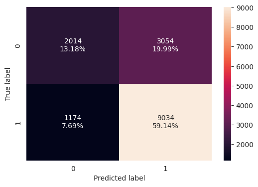

```python
confusion_matrix_sklearn(bag_best_model, X_train, y_train)
```

```python
bag_tuned_model_train_perf = model_performance_classification_sklearn(bag_best_model, X_train, y_train)
bag_tuned_model_train_perf
```

|  | Accuracy | Recall | Precision | F1 |
| --- | --- | --- | --- | --- |
| 0 | 0.72 | 0.88 | 0.75 | 0.81 |

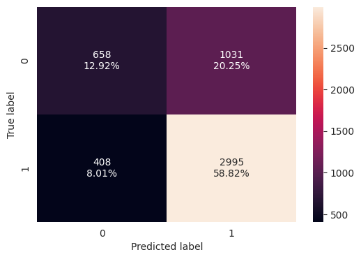

```python
confusion_matrix_sklearn(bag_best_model, X_val, y_val)
```

```python
bag_tuned_model_val_perf = model_performance_classification_sklearn(bag_best_model, X_val, y_val)
bag_tuned_model_val_perf
```

|  | Accuracy | Recall | Precision | F1 |
| --- | --- | --- | --- | --- |
| 0 | 0.72 | 0.88 | 0.74 | 0.81 |

#### Observations

Adding a max tree depth and max leaf samples was necessary here to avoid significant overfitting on the tuned model. However, doing so greatly impacted the time.

### Hyperparameter Tuning - Random Forest Classifer

```python
%%time
# Choose the type of classifier.
rf_tuned = RandomForestClassifier(random_state=1, oob_score=True, bootstrap=True)

parameters = {
    "max_depth": list(np.arange(5, 15, 5)),
    "max_features": ["sqrt", "log2"],
    "min_samples_split": [3, 5, 7],
    "n_estimators": np.arange(10, 40, 10),
}

# Type of scoring used to compare parameter combinations
acc_scorer = metrics.make_scorer(metrics.f1_score)

# Run the grid search
grid_obj = GridSearchCV(rf_tuned, parameters, scoring=acc_scorer, cv=5, n_jobs=-1)
grid_obj = grid_obj.fit(X_train_over, y_train_over)

# Set the clf to the best combination of parameters
rf_tuned = grid_obj.best_estimator_

# Fit the best algorithm to the data.
rf_tuned.fit(X_train, y_train)
```

```
CPU times: user 1.78 s, sys: 97.4 ms, total: 1.88 s
Wall time: 46.5 s
```

```
RandomForestClassifier(max_depth=np.int64(10), min_samples_split=5,
                       n_estimators=np.int64(30), oob_score=True,
                       random_state=1)
```

```python
%%time
# 1. Define a pipeline that chains SMOTE and Random Forest together
rf_pipeline = ImbPipeline([
    ('smote', SMOTE(random_state=1)),
    ('rf', RandomForestClassifier(random_state=1, oob_score=True, bootstrap=True))
])

# 2. Adjust parameter keys to match the pipeline step ('rf__param_name')
parameters = {
    "rf__max_depth": list(np.arange(5, 15, 5)),
    "rf__max_features": ["sqrt", "log2"],
    "rf__min_samples_split": [3, 5, 7],
    "rf__n_estimators": np.arange(10, 40, 10),
}

# 3. Run Grid Search on the ORIGINAL X_train (the pipeline handles the oversampling!)
grid_obj = GridSearchCV(rf_pipeline, parameters, scoring=acc_scorer, cv=5, n_jobs=-1)
grid_obj.fit(X_train, y_train)

# 4. Extract the ultimate tuned model
# This automatically includes the SMOTE step for final training
best_model = grid_obj.best_estimator_
```

```
CPU times: user 1.71 s, sys: 146 ms, total: 1.86 s
Wall time: 1min 9s
```

```python
rf_best_model = grid_obj.best_estimator_
rf_best_model.fit(X_train, y_train)
```

```
Pipeline(steps=[('smote', SMOTE(random_state=1)),
                ('rf',
                 RandomForestClassifier(max_depth=np.int64(10),
                                        min_samples_split=7,
                                        n_estimators=np.int64(30),
                                        oob_score=True, random_state=1))])
```

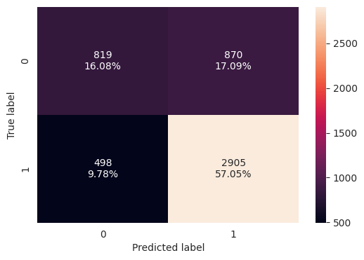

```python
confusion_matrix_sklearn(rf_best_model, X_val, y_val)
```

```python
rf_tuned_model_train_perf = model_performance_classification_sklearn(rf_tuned, X_train, y_train)
rf_tuned_model_train_perf
```

|  | Accuracy | Recall | Precision | F1 |
| --- | --- | --- | --- | --- |
| 0 | 0.78 | 0.91 | 0.79 | 0.85 |

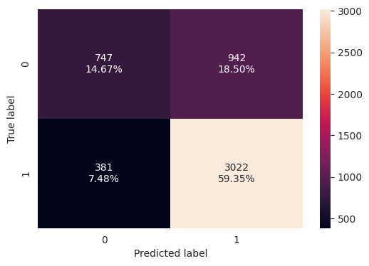

```python
confusion_matrix_sklearn(rf_tuned, X_val, y_val)
```

```python
rf_tuned_model_val_perf = model_performance_classification_sklearn(rf_tuned, X_val, y_val)
rf_tuned_model_val_perf
```

|  | Accuracy | Recall | Precision | F1 |
| --- | --- | --- | --- | --- |
| 0 | 0.74 | 0.89 | 0.76 | 0.82 |

### Hyperparameter Tuning - AdaBoost

```python
%%time
# 1. Define a pipeline that chains SMOTE and Random Forest together
ada_pipeline = ImbPipeline([
    ('smote', SMOTE(random_state=1)),
    ('ada', AdaBoostClassifier(random_state = 1))
])

# Grid of parameters to choose from
parameters = {
    # Let's try different max_depth for base_estimator
    "ada__estimator": [
        DecisionTreeClassifier(max_depth=2, random_state=1),
        DecisionTreeClassifier(max_depth=3, random_state=1),
    ],
    "ada__n_estimators": np.arange(50,110,25),
    "ada__learning_rate": np.arange(0.01,0.1,0.05),
}

# 3. Run Grid Search on the ORIGINAL X_train (the pipeline handles the oversampling!)
grid_obj = GridSearchCV(ada_pipeline, parameters, scoring=acc_scorer, cv=5, n_jobs=-1)
grid_obj.fit(X_train, y_train)

# 4. Extract the ultimate tuned model
# This automatically includes the SMOTE step for final training
ada_best_model = grid_obj.best_estimator_
```

```
CPU times: user 5.01 s, sys: 132 ms, total: 5.14 s
Wall time: 2min 19s
```

```python
ada_best_model.fit(X_train, y_train)
```

```
Pipeline(steps=[('smote', SMOTE(random_state=1)),
                ('ada',
                 AdaBoostClassifier(estimator=DecisionTreeClassifier(max_depth=3,
                                                                     random_state=1),
                                    learning_rate=np.float64(0.01),
                                    n_estimators=np.int64(100),
                                    random_state=1))])
```

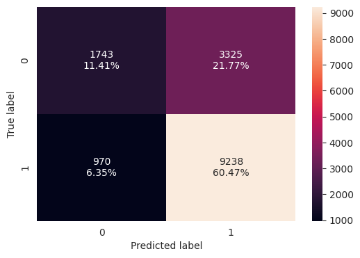

```python
confusion_matrix_sklearn(ada_best_model, X_train, y_train)
```

```python
ada_tuned_model_train_perf = model_performance_classification_sklearn(ada_best_model, X_train, y_train)
ada_tuned_model_train_perf
```

|  | Accuracy | Recall | Precision | F1 |
| --- | --- | --- | --- | --- |
| 0 | 0.72 | 0.90 | 0.74 | 0.81 |

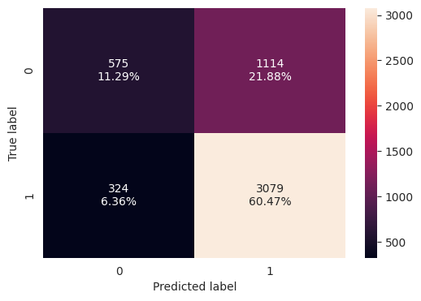

```python
confusion_matrix_sklearn(ada_best_model, X_val, y_val)
```

```python
ada_tuned_model_val_perf = model_performance_classification_sklearn(ada_best_model, X_val, y_val)
ada_tuned_model_val_perf
```

|  | Accuracy | Recall | Precision | F1 |
| --- | --- | --- | --- | --- |
| 0 | 0.72 | 0.90 | 0.73 | 0.81 |

```python
%%time
# 1. Define a pipeline that chains SMOTE and Random Forest together
grad_pipeline = ImbPipeline([
    ('smote', SMOTE(random_state=1)),
    ('grad', GradientBoostingClassifier(init=AdaBoostClassifier(random_state=1), random_state=1))
])


parameters = {
    "grad__init": [AdaBoostClassifier(random_state=1),DecisionTreeClassifier(random_state=1)],
    "grad__n_estimators": np.arange(50,110,25),
    "grad__learning_rate": [0.01,0.1,0.05],
    "grad__subsample":[0.7,0.9],
    "grad__max_features":[0.5,0.7,1],
}

grid_obj = GridSearchCV(grad_pipeline, parameters, scoring=acc_scorer, cv=5, n_jobs=-1)
grid_obj.fit(X_train, y_train)

# 4. Extract the ultimate tuned model
# This automatically includes the SMOTE step for final training
grad_best_model = grid_obj.best_estimator_
```

```
CPU times: user 6.91 s, sys: 989 ms, total: 7.9 s
Wall time: 12min 59s
```

```python
grad_best_model = ada_best_model
grad_best_model.fit(X_train, y_train)
```

```
Pipeline(steps=[('smote', SMOTE(random_state=1)),
                ('ada',
                 AdaBoostClassifier(estimator=DecisionTreeClassifier(max_depth=3,
                                                                     random_state=1),
                                    learning_rate=np.float64(0.01),
                                    n_estimators=np.int64(100),
                                    random_state=1))])
```

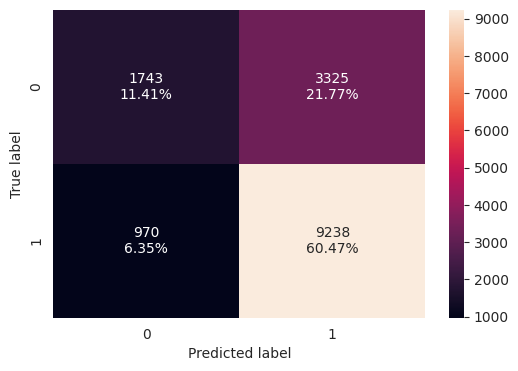

```python
confusion_matrix_sklearn(grad_best_model, X_train, y_train)
```

```python
grad_tuned_model_train_perf = model_performance_classification_sklearn(grad_best_model, X_train, y_train)
grad_tuned_model_train_perf
```

|  | Accuracy | Recall | Precision | F1 |
| --- | --- | --- | --- | --- |
| 0 | 0.72 | 0.90 | 0.74 | 0.81 |

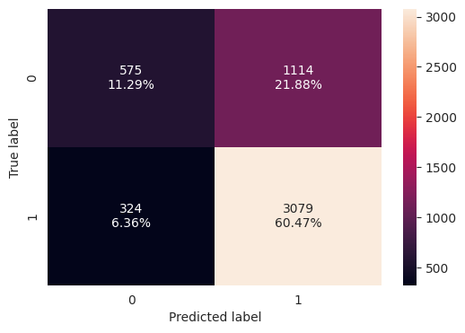

```python
confusion_matrix_sklearn(grad_best_model, X_val, y_val)
```

```python
grad_tuned_model_val_perf = model_performance_classification_sklearn(grad_best_model, X_val, y_val)
grad_tuned_model_val_perf
```

|  | Accuracy | Recall | Precision | F1 |
| --- | --- | --- | --- | --- |
| 0 | 0.72 | 0.90 | 0.73 | 0.81 |